# Project: Analysis of Goverment Gun Control in the US

- Introduction
- Data Cleaning for Gun Data
- Data Cleaning for Census Data
- Exploratory Data Analysis
- Conclusions

## Introduction

```
I chose FBI Gun Dataset for this project. It provided two databases:
```

a) FBI Gun Data from Nov 1998 to Sep 2017. It contains the number of firearm checks (not sales) by month, state, and type. The data comes from the FBI's National Instant Criminal Background Check System (NICS). The NICS is used by to determine whether a prospective buyer is eligible to buy firearms or explosives. Gun shops call into this system to ensure that each customer does not have a criminal record or isn’t otherwise ineligible to make a purchase. Although this data does not provide actual gun sales, gun checks is still an indication of the volume of sales in each state over the years.

b) US Census Data. Most variables just have one data point per state (2016), but a few have data for more than one year.

```
Here are a few questions that could be answered by analyzing the two datasets.
```

1 - Comparison of firearm checks by state

2 - Anual trends of firearm checks

3 - Comparing hand-gun vs long-gun checks, and trends throuout years

4 - Gun checks compared to population, by state

5 - Is gun checks by state linked to % of Blacks, Hispanic, Asian, Whites (2016)

6 - Is gun checks by state linked to % Veterans (2016)

7 - Is gun checks by state linked to % of Foreign born persons (2016)

8 - Who buys more guns, women or men? and how is that changing over the years?

9 - Do we see a correlation with the education?

10 - How about a correlation with houseold income level?

11- Is percentege of persons in powerty correlated to gun checks?

12- What about employment? How do employment levels correlate with gun checks?

13- It would also ve very interseting to see how population density affects gun checks

14- And last: is time to work travel a factor?

```
I am going to answer these five:
```

1- Anual trends of firearm checks

2- Seasonality (monthly) trends for firearm checks in 2016. How has tha changed throughout the years? How 2016 compares to the monthly aggregated data from 1998-2017?

3- What state trend diferences can we see for firearm checks for the period 1998-2017? and for 2016 alone?

4- It is hard to draw any conclussions on gun state prevalence without bringing state population into the formula. I am going to make an analisys where I calculate the total number of gun permits for each state/1000 people

5- I also want to know if firearm permit checks is related to other factors like age, income level, education, gender and diversity

```python
##Import all the necesary libraries
import numpy as np
import pandas as pd
import matplotlib.pyplot as plt
import csv
import seaborn as sns
%matplotlib inline
%pylab inline
```

```python
##Importing the datafiles. I am using panda libraries.
census_data = pd.read_csv('U.S. Census Data.csv')
gun_data = pd.read_excel('gun_data.xlsx')
```

```python
print ('Number of columns in Gun Data is', len(gun_data.columns), 'and number of rows is', len(gun_data.index))
print ('Number of columns in Census Data is', len(census_data.columns), 'and number of rows is', len(census_data.index))
```

```
Number of columns in Gun Data is 27 and number of rows is 12485
Number of columns in Census Data is 52 and number of rows is 85
```

Checking the size of the datafiles. We have 27 coulnms and 12485 rows in the Gun Data set. For the US census data, we have 52 coulmns and 85 rows.

```python
gun_data.head()
```

|  | month | state | permit | permit_recheck | handgun | long_gun | other | multiple | admin | prepawn_handgun | ... | returned_other | rentals_handgun | rentals_long_gun | private_sale_handgun | private_sale_long_gun | private_sale_other | return_to_seller_handgun | return_to_seller_long_gun | return_to_seller_other | totals |
| --- | --- | --- | --- | --- | --- | --- | --- | --- | --- | --- | --- | --- | --- | --- | --- | --- | --- | --- | --- | --- | --- |
| 0 | 2017-09 | Alabama | 16717.0 | 0.0 | 5734.0 | 6320.0 | 221.0 | 317 | 0.0 | 15.0 | ... | 0.0 | 0.0 | 0.0 | 9.0 | 16.0 | 3.0 | 0.0 | 0.0 | 3.0 | 32019 |
| 1 | 2017-09 | Alaska | 209.0 | 2.0 | 2320.0 | 2930.0 | 219.0 | 160 | 0.0 | 5.0 | ... | 0.0 | 0.0 | 0.0 | 17.0 | 24.0 | 1.0 | 0.0 | 0.0 | 0.0 | 6303 |
| 2 | 2017-09 | Arizona | 5069.0 | 382.0 | 11063.0 | 7946.0 | 920.0 | 631 | 0.0 | 13.0 | ... | 0.0 | 0.0 | 0.0 | 38.0 | 12.0 | 2.0 | 0.0 | 0.0 | 0.0 | 28394 |
| 3 | 2017-09 | Arkansas | 2935.0 | 632.0 | 4347.0 | 6063.0 | 165.0 | 366 | 51.0 | 12.0 | ... | 0.0 | 0.0 | 0.0 | 13.0 | 23.0 | 0.0 | 0.0 | 2.0 | 1.0 | 17747 |
| 4 | 2017-09 | California | 57839.0 | 0.0 | 37165.0 | 24581.0 | 2984.0 | 0 | 0.0 | 0.0 | ... | 0.0 | 0.0 | 0.0 | 0.0 | 0.0 | 0.0 | 0.0 | 0.0 | 0.0 | 123506 |

5 rows × 27 columns

```python
##What type of data is it?
gun_data.dtypes.head()
```

```
month              object
state              object
permit            float64
permit_recheck    float64
handgun           float64
dtype: object
```

```python
census_data.head()
```

|  | Fact | Fact Note | Alabama | Alaska | Arizona | Arkansas | California | Colorado | Connecticut | Delaware | ... | South Dakota | Tennessee | Texas | Utah | Vermont | Virginia | Washington | West Virginia | Wisconsin | Wyoming |
| --- | --- | --- | --- | --- | --- | --- | --- | --- | --- | --- | --- | --- | --- | --- | --- | --- | --- | --- | --- | --- | --- |
| 0 | Population estimates, July 1, 2016, (V2016) | NaN | 4,863,300 | 741,894 | 6,931,071 | 2,988,248 | 39,250,017 | 5,540,545 | 3,576,452 | 952,065 | ... | 865454 | 6651194 | 27,862,596 | 3,051,217 | 624,594 | 8,411,808 | 7,288,000 | 1,831,102 | 5,778,708 | 585,501 |
| 1 | Population estimates base, April 1, 2010, (V2... | NaN | 4,780,131 | 710,249 | 6,392,301 | 2,916,025 | 37,254,522 | 5,029,324 | 3,574,114 | 897,936 | ... | 814195 | 6346298 | 25,146,100 | 2,763,888 | 625,741 | 8,001,041 | 6,724,545 | 1,853,011 | 5,687,289 | 563,767 |
| 2 | Population, percent change - April 1, 2010 (es... | NaN | 1.70% | 4.50% | 8.40% | 2.50% | 5.40% | 10.20% | 0.10% | 6.00% | ... | 0.063 | 0.048 | 10.80% | 10.40% | -0.20% | 5.10% | 8.40% | -1.20% | 1.60% | 3.90% |
| 3 | Population, Census, April 1, 2010 | NaN | 4,779,736 | 710,231 | 6,392,017 | 2,915,918 | 37,253,956 | 5,029,196 | 3,574,097 | 897,934 | ... | 814180 | 6346105 | 25,145,561 | 2,763,885 | 625,741 | 8,001,024 | 6,724,540 | 1,852,994 | 5,686,986 | 563,626 |
| 4 | Persons under 5 years, percent, July 1, 2016, ... | NaN | 6.00% | 7.30% | 6.30% | 6.40% | 6.30% | 6.10% | 5.20% | 5.80% | ... | 0.071 | 0.061 | 7.20% | 8.30% | 4.90% | 6.10% | 6.20% | 5.50% | 5.80% | 6.50% |

5 rows × 52 columns

```python
## What type of data is it?
census_data.dtypes.head()
```

```
Fact         object
Fact Note    object
Alabama      object
Alaska       object
Arizona      object
dtype: object
```

In the previous code blocks I checked the data, type of data and null data. For the gun_data file, out of the 27 columns, most of them were floats, month and state were objects and multiple and totals were integers. For the census_data file, it looks like they were all objects.

In the following code blocks I will check the number of nulls and duplicates in the datafile.

```python
gun_data.isnull().sum().head()
```

```
month                 0
state                 0
permit               24
permit_recheck    11385
handgun              20
dtype: int64
```

```python
census_data.isnull().sum().head()
```

```
Fact          5
Fact Note    57
Alabama      20
Alaska       20
Arizona      20
dtype: int64
```

```python
##The following code tells us how many duplicates are in the datafiles
print ('Number of duplicates in gun_data file is', sum(gun_data.duplicated()))
print ('Number of duplicates in census_data file is', sum(census_data.duplicated()))
```

```
Number of duplicates in gun_data file is 0
Number of duplicates in census_data file is 3
```

# Data Cleaning for Gun Data

In the following code blocks I have done the following:

1) Format the date column so it is easier to work with. This way I will be able to select specific years and look at monthly trends.

2) Selected and organized the columns I will be working with.

3) Investigated the dataset to see if there were duplicates and nulls. We have no duplicates, but an insignificant number of nulls.

4) Substituted the nulls, first with zero values, then with the mean. It is better to use the mean values as substitutes for the nulls. The overall mean in each column is not affected as much.

```python
##In this code, I will split the data column (YYYY-MM) into two separate columns (YYYY) and (MM)
gun_data['year'] = gun_data['month'].apply(lambda x: x.split("-")[0]).astype(int)
gun_data['year'].head()

gun_data['month'] = gun_data['month'].apply(lambda x: x.split("-")[1]).astype(int)
gun_data['month'].head()
```

```
0    9
1    9
2    9
3    9
4    9
Name: month, dtype: int64
```

```python
##Selected and re-arranged the columns I will be using during the analysis to answer the Qs The rest, I dont need.
gun_data = gun_data [['year', 'month', 'state', 'permit', 'handgun', 'long_gun', 'totals']]
```

```python
gun_data.head()
```

|  | year | month | state | permit | handgun | long_gun | totals |
| --- | --- | --- | --- | --- | --- | --- | --- |
| 0 | 2017 | 9 | Alabama | 16717.0 | 5734.0 | 6320.0 | 32019 |
| 1 | 2017 | 9 | Alaska | 209.0 | 2320.0 | 2930.0 | 6303 |
| 2 | 2017 | 9 | Arizona | 5069.0 | 11063.0 | 7946.0 | 28394 |
| 3 | 2017 | 9 | Arkansas | 2935.0 | 4347.0 | 6063.0 | 17747 |
| 4 | 2017 | 9 | California | 57839.0 | 37165.0 | 24581.0 | 123506 |

```python
##check for null data
gun_data.isnull().sum()
```

```
year         0
month        0
state        0
permit      24
handgun     20
long_gun    19
totals       0
dtype: int64
```

```python
##run some descriptive statistics for gun data. Calculated the mean for every column
gun_data.mean()
```

```
year         2007.792952
month           6.484581
permit       6413.629404
handgun      5940.881107
long_gun     7810.847585
totals      21595.725911
dtype: float64
```

```python
##In this block and for each column, I substituted all null data with the mean, then with zero. Then run the describe
##function in each case. When I substituted the nulls with zero value, the mean was altered. So I chose the
##mean as a substitute for the null values.
gun_data_with_mean = gun_data.fillna(gun_data.mean())
gun_data_with_zero = gun_data.fillna(0)
print (gun_data_with_mean.mean())
print (gun_data_with_zero.mean())
```

```
year         2007.792952
month           6.484581
permit       6413.629404
handgun      5940.881107
long_gun     7810.847585
totals      21595.725911
dtype: float64
year         2007.792952
month           6.484581
permit       6401.300441
handgun      5931.364277
long_gun     7798.960833
totals      21595.725911
dtype: float64
```

# Data Cleaning for Census Data

Here, I have done the following:

1) Checked for nulls.

2) Deleted column 1, since it has no data. Also, all the rows from 65 on. They are mosly comment rows.

3) Checked for duplicates (got rid of them, if needed).

```python
#census_data.isnull().sum()
```

```python
##Delete column 1 and rows 65 and on
census_data = census_data.drop(census_data.columns[1], axis=1)
census_data = census_data.drop(census_data.index[65:])
census_data.head()
```

|  | Fact | Alabama | Alaska | Arizona | Arkansas | California | Colorado | Connecticut | Delaware | Florida | ... | South Dakota | Tennessee | Texas | Utah | Vermont | Virginia | Washington | West Virginia | Wisconsin | Wyoming |
| --- | --- | --- | --- | --- | --- | --- | --- | --- | --- | --- | --- | --- | --- | --- | --- | --- | --- | --- | --- | --- | --- |
| 0 | Population estimates, July 1, 2016, (V2016) | 4,863,300 | 741,894 | 6,931,071 | 2,988,248 | 39,250,017 | 5,540,545 | 3,576,452 | 952,065 | 20,612,439 | ... | 865454 | 6651194 | 27,862,596 | 3,051,217 | 624,594 | 8,411,808 | 7,288,000 | 1,831,102 | 5,778,708 | 585,501 |
| 1 | Population estimates base, April 1, 2010, (V2... | 4,780,131 | 710,249 | 6,392,301 | 2,916,025 | 37,254,522 | 5,029,324 | 3,574,114 | 897,936 | 18,804,592 | ... | 814195 | 6346298 | 25,146,100 | 2,763,888 | 625,741 | 8,001,041 | 6,724,545 | 1,853,011 | 5,687,289 | 563,767 |
| 2 | Population, percent change - April 1, 2010 (es... | 1.70% | 4.50% | 8.40% | 2.50% | 5.40% | 10.20% | 0.10% | 6.00% | 9.60% | ... | 0.063 | 0.048 | 10.80% | 10.40% | -0.20% | 5.10% | 8.40% | -1.20% | 1.60% | 3.90% |
| 3 | Population, Census, April 1, 2010 | 4,779,736 | 710,231 | 6,392,017 | 2,915,918 | 37,253,956 | 5,029,196 | 3,574,097 | 897,934 | 18,801,310 | ... | 814180 | 6346105 | 25,145,561 | 2,763,885 | 625,741 | 8,001,024 | 6,724,540 | 1,852,994 | 5,686,986 | 563,626 |
| 4 | Persons under 5 years, percent, July 1, 2016, ... | 6.00% | 7.30% | 6.30% | 6.40% | 6.30% | 6.10% | 5.20% | 5.80% | 5.50% | ... | 0.071 | 0.061 | 7.20% | 8.30% | 4.90% | 6.10% | 6.20% | 5.50% | 5.80% | 6.50% |

5 rows × 51 columns

```python
##Conveniently enough, removing the null cells, got rid of the duplicates as well
##The number of duplicates in the datafile is ZERO now
print ('Now, number of duplicates in census_data file is', sum(census_data.duplicated()))
```

```
Now, number of duplicates in census_data file is 0
```

In the following code blocks, I formated the datafile elements, getting rid of simbols and converting them into numerical data.

```python
##First, I create a list called USA States so that I can loop over it
USA_States = list(census_data.columns.values)
print (USA_States)
```

```
['Fact', 'Alabama', 'Alaska', 'Arizona', 'Arkansas', 'California', 'Colorado', 'Connecticut', 'Delaware', 'Florida', 'Georgia', 'Hawaii', 'Idaho', 'Illinois', 'Indiana', 'Iowa', 'Kansas', 'Kentucky', 'Louisiana', 'Maine', 'Maryland', 'Massachusetts', 'Michigan', 'Minnesota', 'Mississippi', 'Missouri…
```

```python
##Then, I delete the first element of the series, FACT. I am not looping over it
USA_States = USA_States[1:]
print (USA_States)
```

```
['Alabama', 'Alaska', 'Arizona', 'Arkansas', 'California', 'Colorado', 'Connecticut', 'Delaware', 'Florida', 'Georgia', 'Hawaii', 'Idaho', 'Illinois', 'Indiana', 'Iowa', 'Kansas', 'Kentucky', 'Louisiana', 'Maine', 'Maryland', 'Massachusetts', 'Michigan', 'Minnesota', 'Mississippi', 'Missouri', 'Mont…
```

```python
##Cells containing percentage numbers are not consistent. To make them all consistent I will multiply those decimel
##number cells by 100. I create a function called multH (multiply by hundred).
def multH(value):
    entero = value
    if value <1.0:
        entero = value *100.0
    return entero
```

```python
##In this code below I am formating the data. getting rid of simbols (%, etc). Then, I turn them into numerical
##values. Then apply the multH function to the census_data file.
for x in USA_States:
    census_data[x].replace(regex=True, inplace=True, to_replace = r'[^\d.-]', value = r'')
    census_data[x] = pd.to_numeric(census_data[x], downcast='float', errors='ignore')
    census_data[x] = census_data[x].apply(multH)
```

```python
census_data.head()
```

|  | Fact | Alabama | Alaska | Arizona | Arkansas | California | Colorado | Connecticut | Delaware | Florida | ... | South Dakota | Tennessee | Texas | Utah | Vermont | Virginia | Washington | West Virginia | Wisconsin | Wyoming |
| --- | --- | --- | --- | --- | --- | --- | --- | --- | --- | --- | --- | --- | --- | --- | --- | --- | --- | --- | --- | --- | --- |
| 0 | Population estimates, July 1, 2016, (V2016) | 4863300.0 | 741894.0 | 6931071.0 | 2988248.0 | 39250016.0 | 5540545.0 | 3576452.0 | 952065.0 | 20612440.0 | ... | 865454.0 | 6651194.0 | 27862596.0 | 3051217.0 | 624594.0 | 8411808.0 | 7288000.0 | 1.831102e+06 | 5778708.0 | 585501.0 |
| 1 | Population estimates base, April 1, 2010, (V2... | 4780131.0 | 710249.0 | 6392301.0 | 2916025.0 | 37254520.0 | 5029324.0 | 3574114.0 | 897936.0 | 18804592.0 | ... | 814195.0 | 6346298.0 | 25146100.0 | 2763888.0 | 625741.0 | 8001041.0 | 6724545.0 | 1.853011e+06 | 5687289.0 | 563767.0 |
| 2 | Population, percent change - April 1, 2010 (es... | 1.7 | 4.5 | 8.4 | 2.5 | 5.4 | 10.2 | 10.0 | 6.0 | 9.6 | ... | 6.3 | 4.8 | 10.8 | 10.4 | -20.0 | 5.1 | 8.4 | -1.200000e+02 | 1.6 | 3.9 |
| 3 | Population, Census, April 1, 2010 | 4779736.0 | 710231.0 | 6392017.0 | 2915918.0 | 37253956.0 | 5029196.0 | 3574097.0 | 897934.0 | 18801310.0 | ... | 814180.0 | 6346105.0 | 25145560.0 | 2763885.0 | 625741.0 | 8001024.0 | 6724540.0 | 1.852994e+06 | 5686986.0 | 563626.0 |
| 4 | Persons under 5 years, percent, July 1, 2016, ... | 6.0 | 7.3 | 6.3 | 6.4 | 6.3 | 6.1 | 5.2 | 5.8 | 5.5 | ... | 7.1 | 6.1 | 7.2 | 8.3 | 4.9 | 6.1 | 6.2 | 5.500000e+00 | 5.8 | 6.5 |

5 rows × 51 columns

# What are the trends for firearms permit checks?

In this block I will focus on answering the first three questions. They can all be answered by analyzing the gun datafile.

The FIRST question is: what are the anual trends of firearm checks? I will look at the gun total permits column and group it by year. I can do that because I now have a year column.

```python
##let's take a look inside the datafile again
gun_data.head()
```

|  | year | month | state | permit | handgun | long_gun | totals |
| --- | --- | --- | --- | --- | --- | --- | --- |
| 0 | 2017 | 9 | Alabama | 16717.0 | 5734.0 | 6320.0 | 32019 |
| 1 | 2017 | 9 | Alaska | 209.0 | 2320.0 | 2930.0 | 6303 |
| 2 | 2017 | 9 | Arizona | 5069.0 | 11063.0 | 7946.0 | 28394 |
| 3 | 2017 | 9 | Arkansas | 2935.0 | 4347.0 | 6063.0 | 17747 |
| 4 | 2017 | 9 | California | 57839.0 | 37165.0 | 24581.0 | 123506 |

```python
##Let's group total permits by year
guns_by_year = gun_data.groupby('year')['totals'].sum()
guns_by_year.head(20)
```

```
year
1998      891898
1999     9043747
2000     8427096
2001     8820045
2002     8367069
2003     8402244
2004     8579891
2005     8867055
2006     9993057
2007    11162272
2008    12692985
2009    13984953
2010    14320489
2011    16336732
2012    19463832
2013    20966704
2014    20860241
2015    23026288
2016    27425512
2017    17990528
Name: totals, dtype: int64
```

```
Text(0.5,1,'Frequency of Gun Permit Requests')
```

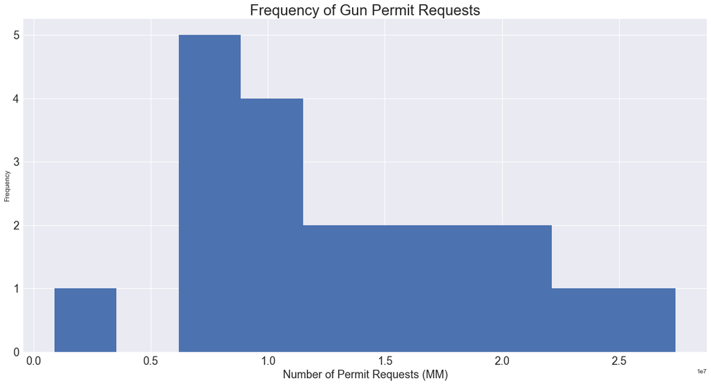

```python
guns_by_year.plot.hist(figsize=(20,10), legend=False, fontsize=18)
plt.xlabel('Number of Permit Requests (MM)', fontsize = 18)
plt.title('Frequency of Gun Permit Requests', fontsize = 24)
```

```python
##let's run some descriptive statistics on it
guns_by_year.describe()
```

```
count    2.000000e+01
mean     1.348113e+07
std      6.497589e+06
min      8.918980e+05
25%      8.760006e+06
50%      1.192763e+07
75%      1.835885e+07
max      2.742551e+07
Name: totals, dtype: float64
```

```
Text(0.5,1,'Annual Gun Permit Trends (1998-2017)')
```

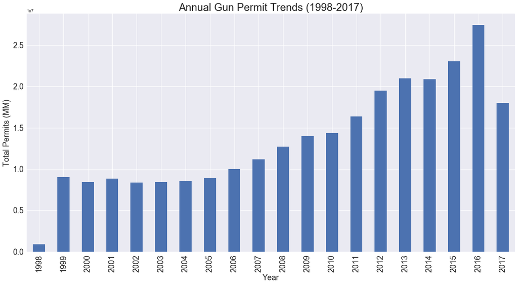

```python
##Now I am ready to graph it. I use the plot function
sns.set()
guns_by_year.plot(x='Year', kind = 'bar', figsize=(20,10), legend=False, fontsize=18)
plt.ylabel('Total Permits (MM)', fontsize = 18)
plt.xlabel('Year', fontsize = 18)
plt.title('Annual Gun Permit Trends (1998-2017)', fontsize = 24)
```

The SECOND question is: what seasonality trends do we observe for firearm checks in 2016. How has tha changed throughout the years? How 2016 compares to the monthly aggregated data of 1998-2017?

First, we are going to take a look at monthly trends for ALL years.

```python
##We group the data by month, for all years 1998-2017
gun_data_month_allyears = gun_data.groupby('month')['totals'].sum()
gun_data_month_allyears.head()
```

```
month
1    22594354
2    24386459
3    25357927
4    21322573
5    18918200
Name: totals, dtype: int64
```

```
Text(0.5,1,'1998-2017 Gun Permits by Month')
```

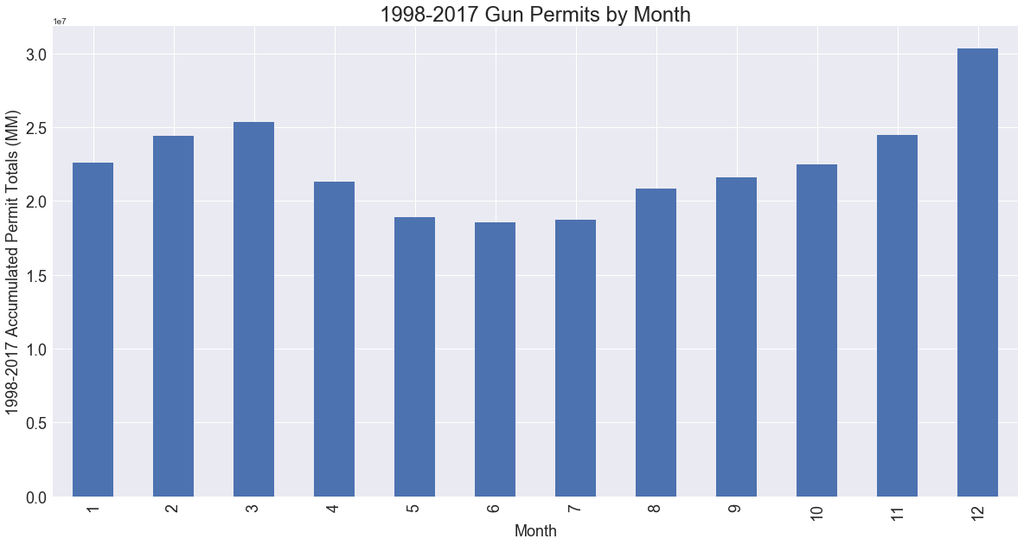

```python
##Now I am ready to graph it. I use the plot function again
gun_data_month_allyears.plot(x='Month', kind = 'bar', figsize=(20,10), legend=False, fontsize=18)
plt.ylabel('1998-2017 Accumulated Permit Totals (MM)', fontsize = 18)
plt.xlabel('Month', fontsize = 18)
plt.title('1998-2017 Gun Permits by Month', fontsize = 24)
```

There are some interesting trends. We observe two peak months, March and December. There is a decrease during spring, right after March and through the month of July. Then gun permits continue to increase steadily until the end of the year. Definetly, firearms must be a very popular Christmast present in the US.

Now, let's analyze 2016 only. Is the lastest year where we have a full year of data. In 2017, we only have data through September.

```python
##Let's slice that year from our dataset
gun_data_2016 = gun_data[gun_data['year'] == 2016]
gun_data_2016.head()
```

|  | year | month | state | permit | handgun | long_gun | totals |
| --- | --- | --- | --- | --- | --- | --- | --- |
| 495 | 2016 | 12 | Alabama | 26996.0 | 13733.0 | 17519.0 | 62014 |
| 496 | 2016 | 12 | Alaska | 254.0 | 4087.0 | 3698.0 | 8786 |
| 497 | 2016 | 12 | Arizona | 8900.0 | 18024.0 | 13785.0 | 44887 |
| 498 | 2016 | 12 | Arkansas | 3294.0 | 9192.0 | 13433.0 | 29926 |
| 499 | 2016 | 12 | California | 61808.0 | 63649.0 | 93224.0 | 298161 |

```python
##Once 2016 is selected, we can proceed to group by month
guns_by_month_2016 = gun_data_2016.groupby('month')['totals'].sum()
guns_by_month_2016.head()
```

```
month
1    2540146
2    2604667
3    2509065
4    2135909
5    1860699
Name: totals, dtype: int64
```

```
Text(0.5,1,'Monthly Gun Permit Trends (2016)')
```

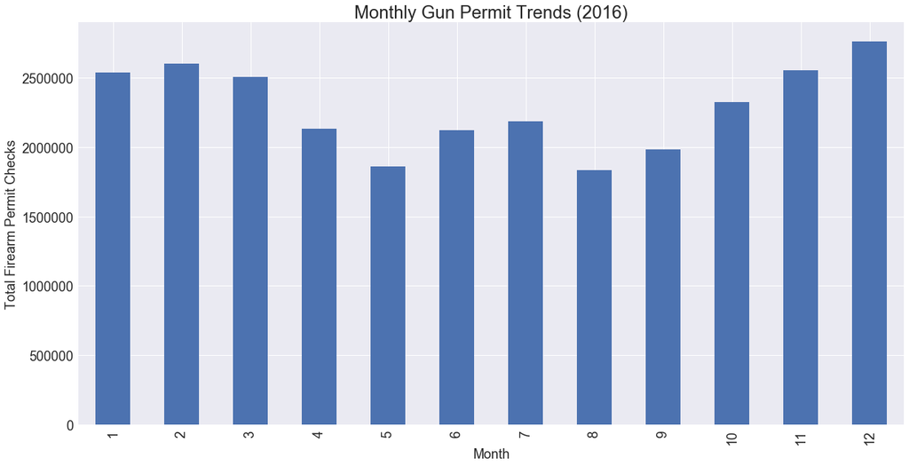

```python
##Now, let's graph it, so that we can compare to the aggregated chart.
guns_by_month_2016.plot(x='Month', kind = 'bar', figsize=(20,10), legend=False, fontsize=18)
plt.ylabel('Total Firearm Permit Checks', fontsize = 18)
plt.xlabel('Month', fontsize = 18)
plt.title('Monthly Gun Permit Trends (2016)', fontsize = 24)
```

In the previous chart, we take a look at 2016 only. We see the same monthly trends although we see an increase during June and July. There could be two reasons for this: people are buying firearms for summer gun-related sports (hunting) - less likely since we would have also seen that happen in the previous graph - or the fact that the US was in pre-election mode. The political campaign, the visibility of the NRA amd the scary messages broadcast by some media outlets might have played a role.

The THIRD question is: what STATE trend diferences can we see for firearm checks for the period 1998-2017? and for 2016 alone?

```python
##We group total data (all years) by state.
gun_data_state = gun_data.groupby('state')['totals'].sum()
gun_data_state.idxmax()
gun_data_state.head()
```

```
state
Alabama        6706079
Alaska         1137643
Arizona        4425714
Arkansas       3752633
California    19014063
Name: totals, dtype: int64
```

```
Text(0.5,1,'Gun Permits by State (1998-2017)')
```

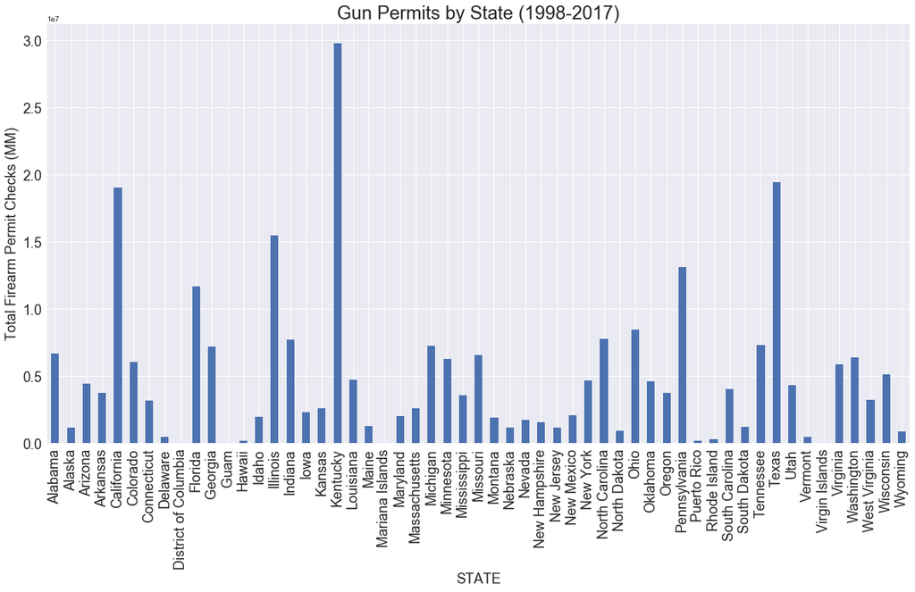

```python
##Then we plot it.
gun_data_state.plot(x='state', kind = 'bar', figsize=(20,10), legend=False, fontsize=18)
plt.xlabel('STATE', fontsize = 18)
plt.ylabel('Total Firearm Permit Checks (MM)', fontsize = 18)
plt.title('Gun Permits by State (1998-2017)', fontsize = 24)
```

Something immediately stands out: the state of Kentucky is the largest state in terms of firearm checks. California and Texas are next, followed by Illinois, Pensylvania and Florida. Mariana Islands is the lowest. It is hard to make real comparisons, unless we bring population data into the picture. I will do that in the next section.

```python
#We look at 2016 only, by state
guns_by_state_2016 = gun_data_2016.groupby('state')['totals'].sum().reset_index()
```

```python
guns_by_state_2016.head()
```

|  | state | totals |
| --- | --- | --- |
| 0 | Alabama | 616947 |
| 1 | Alaska | 87647 |
| 2 | Arizona | 416279 |
| 3 | Arkansas | 266014 |
| 4 | California | 2377167 |

```
Text(0.5,1,'Gun Permits by State (2016)')
```

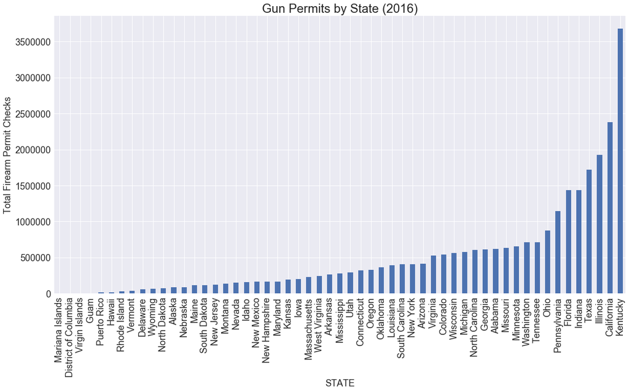

```python
##We plot again
guns_by_state_2016.sort_index(by=['totals'], ascending= True).plot(x='state', kind = 'bar', figsize=(20,10), legend=False, fontsize=18)
plt.ylabel('Total Firearm Permit Checks', fontsize = 18)
plt.xlabel('STATE', fontsize = 18)
plt.title('Gun Permits by State (2016)', fontsize = 24)
```

This chart is very similar to the previous one, where we looked at 1998-2017. We do observe similar trends when we look at 2016 only. Kentucky is by far the highest, then California, Illinois, Texas, Indiana, Florida and Pennsylvania. In the next section, we will add population data, so that we can compare not just absolute numbers, but relative to population.

## Combining and analyzing both datasets

The FOURTH set of questions will address gun prevalence, compared to population. I am going to make an analisys where I calculate the total number of gun permits for each state per 1000 people.

First of all, we need to combine both datasets so that we can do operations with them and answer the questions.

```python
census_data.head()
```

|  | Fact | Alabama | Alaska | Arizona | Arkansas | California | Colorado | Connecticut | Delaware | Florida | ... | South Dakota | Tennessee | Texas | Utah | Vermont | Virginia | Washington | West Virginia | Wisconsin | Wyoming |
| --- | --- | --- | --- | --- | --- | --- | --- | --- | --- | --- | --- | --- | --- | --- | --- | --- | --- | --- | --- | --- | --- |
| 0 | Population estimates, July 1, 2016, (V2016) | 4863300.0 | 741894.0 | 6931071.0 | 2988248.0 | 39250016.0 | 5540545.0 | 3576452.0 | 952065.0 | 20612440.0 | ... | 865454.0 | 6651194.0 | 27862596.0 | 3051217.0 | 624594.0 | 8411808.0 | 7288000.0 | 1.831102e+06 | 5778708.0 | 585501.0 |
| 1 | Population estimates base, April 1, 2010, (V2... | 4780131.0 | 710249.0 | 6392301.0 | 2916025.0 | 37254520.0 | 5029324.0 | 3574114.0 | 897936.0 | 18804592.0 | ... | 814195.0 | 6346298.0 | 25146100.0 | 2763888.0 | 625741.0 | 8001041.0 | 6724545.0 | 1.853011e+06 | 5687289.0 | 563767.0 |
| 2 | Population, percent change - April 1, 2010 (es... | 1.7 | 4.5 | 8.4 | 2.5 | 5.4 | 10.2 | 10.0 | 6.0 | 9.6 | ... | 6.3 | 4.8 | 10.8 | 10.4 | -20.0 | 5.1 | 8.4 | -1.200000e+02 | 1.6 | 3.9 |
| 3 | Population, Census, April 1, 2010 | 4779736.0 | 710231.0 | 6392017.0 | 2915918.0 | 37253956.0 | 5029196.0 | 3574097.0 | 897934.0 | 18801310.0 | ... | 814180.0 | 6346105.0 | 25145560.0 | 2763885.0 | 625741.0 | 8001024.0 | 6724540.0 | 1.852994e+06 | 5686986.0 | 563626.0 |
| 4 | Persons under 5 years, percent, July 1, 2016, ... | 6.0 | 7.3 | 6.3 | 6.4 | 6.3 | 6.1 | 5.2 | 5.8 | 5.5 | ... | 7.1 | 6.1 | 7.2 | 8.3 | 4.9 | 6.1 | 6.2 | 5.500000e+00 | 5.8 | 6.5 |

5 rows × 51 columns

```python
##We set the index to the 'Fact' column
census_data.set_index('Fact', inplace = True)
```

```python
##We switch the colums and rows
census_data_switched = census_data.T.reset_index()
```

```python
census_data_switched.head()
```

| Fact | index | Population estimates, July 1, 2016, (V2016) | Population estimates base, April 1, 2010, (V2016) | Population, percent change - April 1, 2010 (estimates base) to July 1, 2016, (V2016) | Population, Census, April 1, 2010 | Persons under 5 years, percent, July 1, 2016, (V2016) | Persons under 5 years, percent, April 1, 2010 | Persons under 18 years, percent, July 1, 2016, (V2016) | Persons under 18 years, percent, April 1, 2010 | Persons 65 years and over, percent, July 1, 2016, (V2016) | ... | All firms, 2012 | Men-owned firms, 2012 | Women-owned firms, 2012 | Minority-owned firms, 2012 | Nonminority-owned firms, 2012 | Veteran-owned firms, 2012 | Nonveteran-owned firms, 2012 | Population per square mile, 2010 | Land area in square miles, 2010 | FIPS Code |
| --- | --- | --- | --- | --- | --- | --- | --- | --- | --- | --- | --- | --- | --- | --- | --- | --- | --- | --- | --- | --- | --- |
| 0 | Alabama | 4863300.0 | 4780131.0 | 1.7 | 4779736.0 | 6.0 | 6.4 | 22.600000 | 23.700001 | 16.100000 | ... | 374153.0 | 203604.0 | 137630.0 | 92219.0 | 272651.0 | 41943.0 | 316984.0 | 94.400002 | 50645.328125 | 1.0 |
| 1 | Alaska | 741894.0 | 710249.0 | 4.5 | 710231.0 | 7.3 | 7.6 | 25.200001 | 26.400000 | 10.400000 | ... | 68032.0 | 35402.0 | 22141.0 | 13688.0 | 51147.0 | 7953.0 | 56091.0 | 1.200000 | 570640.937500 | 2.0 |
| 2 | Arizona | 6931071.0 | 6392301.0 | 8.4 | 6392017.0 | 6.3 | 7.1 | 23.500000 | 25.500000 | 16.900000 | ... | 499926.0 | 245243.0 | 182425.0 | 135313.0 | 344981.0 | 46780.0 | 427582.0 | 56.299999 | 113594.078125 | 4.0 |
| 3 | Arkansas | 2988248.0 | 2916025.0 | 2.5 | 2915918.0 | 6.4 | 6.8 | 23.600000 | 24.400000 | 16.299999 | ... | 231959.0 | 123158.0 | 75962.0 | 35982.0 | 189029.0 | 25915.0 | 192988.0 | 56.000000 | 52035.480469 | 5.0 |
| 4 | California | 39250016.0 | 37254520.0 | 5.4 | 37253956.0 | 6.3 | 6.8 | 23.200001 | 25.000000 | 13.600000 | ... | 3548449.0 | 1852580.0 | 1320085.0 | 1619857.0 | 1819107.0 | 252377.0 | 3176341.0 | 239.100006 | 155779.218750 | 6.0 |

5 rows × 66 columns

```python
##Rename the column index 'state'
census_data_switched.rename(columns ={'index':'state'},inplace = True)
```

```python
census_data_switched.head()
```

| Fact | state | Population estimates, July 1, 2016, (V2016) | Population estimates base, April 1, 2010, (V2016) | Population, percent change - April 1, 2010 (estimates base) to July 1, 2016, (V2016) | Population, Census, April 1, 2010 | Persons under 5 years, percent, July 1, 2016, (V2016) | Persons under 5 years, percent, April 1, 2010 | Persons under 18 years, percent, July 1, 2016, (V2016) | Persons under 18 years, percent, April 1, 2010 | Persons 65 years and over, percent, July 1, 2016, (V2016) | ... | All firms, 2012 | Men-owned firms, 2012 | Women-owned firms, 2012 | Minority-owned firms, 2012 | Nonminority-owned firms, 2012 | Veteran-owned firms, 2012 | Nonveteran-owned firms, 2012 | Population per square mile, 2010 | Land area in square miles, 2010 | FIPS Code |
| --- | --- | --- | --- | --- | --- | --- | --- | --- | --- | --- | --- | --- | --- | --- | --- | --- | --- | --- | --- | --- | --- |
| 0 | Alabama | 4863300.0 | 4780131.0 | 1.7 | 4779736.0 | 6.0 | 6.4 | 22.600000 | 23.700001 | 16.100000 | ... | 374153.0 | 203604.0 | 137630.0 | 92219.0 | 272651.0 | 41943.0 | 316984.0 | 94.400002 | 50645.328125 | 1.0 |
| 1 | Alaska | 741894.0 | 710249.0 | 4.5 | 710231.0 | 7.3 | 7.6 | 25.200001 | 26.400000 | 10.400000 | ... | 68032.0 | 35402.0 | 22141.0 | 13688.0 | 51147.0 | 7953.0 | 56091.0 | 1.200000 | 570640.937500 | 2.0 |
| 2 | Arizona | 6931071.0 | 6392301.0 | 8.4 | 6392017.0 | 6.3 | 7.1 | 23.500000 | 25.500000 | 16.900000 | ... | 499926.0 | 245243.0 | 182425.0 | 135313.0 | 344981.0 | 46780.0 | 427582.0 | 56.299999 | 113594.078125 | 4.0 |
| 3 | Arkansas | 2988248.0 | 2916025.0 | 2.5 | 2915918.0 | 6.4 | 6.8 | 23.600000 | 24.400000 | 16.299999 | ... | 231959.0 | 123158.0 | 75962.0 | 35982.0 | 189029.0 | 25915.0 | 192988.0 | 56.000000 | 52035.480469 | 5.0 |
| 4 | California | 39250016.0 | 37254520.0 | 5.4 | 37253956.0 | 6.3 | 6.8 | 23.200001 | 25.000000 | 13.600000 | ... | 3548449.0 | 1852580.0 | 1320085.0 | 1619857.0 | 1819107.0 | 252377.0 | 3176341.0 | 239.100006 | 155779.218750 | 6.0 |

5 rows × 66 columns

```python
##Let's print 2016 by state data
guns_by_state_2016.head()
```

|  | state | totals |
| --- | --- | --- |
| 0 | Alabama | 616947 |
| 1 | Alaska | 87647 |
| 2 | Arizona | 416279 |
| 3 | Arkansas | 266014 |
| 4 | California | 2377167 |

```python
##We use the merge function to add the 2016 totals column to our original dataframe.
Final_df = guns_by_state_2016.merge(census_data_switched, on='state', how='inner')
```

```python
Final_df.head()
```

|  | state | totals | Population estimates, July 1, 2016, (V2016) | Population estimates base, April 1, 2010, (V2016) | Population, percent change - April 1, 2010 (estimates base) to July 1, 2016, (V2016) | Population, Census, April 1, 2010 | Persons under 5 years, percent, July 1, 2016, (V2016) | Persons under 5 years, percent, April 1, 2010 | Persons under 18 years, percent, July 1, 2016, (V2016) | Persons under 18 years, percent, April 1, 2010 | ... | All firms, 2012 | Men-owned firms, 2012 | Women-owned firms, 2012 | Minority-owned firms, 2012 | Nonminority-owned firms, 2012 | Veteran-owned firms, 2012 | Nonveteran-owned firms, 2012 | Population per square mile, 2010 | Land area in square miles, 2010 | FIPS Code |
| --- | --- | --- | --- | --- | --- | --- | --- | --- | --- | --- | --- | --- | --- | --- | --- | --- | --- | --- | --- | --- | --- |
| 0 | Alabama | 616947 | 4863300.0 | 4780131.0 | 1.7 | 4779736.0 | 6.0 | 6.4 | 22.600000 | 23.700001 | ... | 374153.0 | 203604.0 | 137630.0 | 92219.0 | 272651.0 | 41943.0 | 316984.0 | 94.400002 | 50645.328125 | 1.0 |
| 1 | Alaska | 87647 | 741894.0 | 710249.0 | 4.5 | 710231.0 | 7.3 | 7.6 | 25.200001 | 26.400000 | ... | 68032.0 | 35402.0 | 22141.0 | 13688.0 | 51147.0 | 7953.0 | 56091.0 | 1.200000 | 570640.937500 | 2.0 |
| 2 | Arizona | 416279 | 6931071.0 | 6392301.0 | 8.4 | 6392017.0 | 6.3 | 7.1 | 23.500000 | 25.500000 | ... | 499926.0 | 245243.0 | 182425.0 | 135313.0 | 344981.0 | 46780.0 | 427582.0 | 56.299999 | 113594.078125 | 4.0 |
| 3 | Arkansas | 266014 | 2988248.0 | 2916025.0 | 2.5 | 2915918.0 | 6.4 | 6.8 | 23.600000 | 24.400000 | ... | 231959.0 | 123158.0 | 75962.0 | 35982.0 | 189029.0 | 25915.0 | 192988.0 | 56.000000 | 52035.480469 | 5.0 |
| 4 | California | 2377167 | 39250016.0 | 37254520.0 | 5.4 | 37253956.0 | 6.3 | 6.8 | 23.200001 | 25.000000 | ... | 3548449.0 | 1852580.0 | 1320085.0 | 1619857.0 | 1819107.0 | 252377.0 | 3176341.0 | 239.100006 | 155779.218750 | 6.0 |

5 rows × 67 columns

```python
##Renamed "totals" column to "Totals 2016"
Final_df.rename(columns ={'totals': "Totals 2016"},inplace = True)
```

```python
Final_df.head()
```

|  | state | Totals 2016 | Population estimates, July 1, 2016, (V2016) | Population estimates base, April 1, 2010, (V2016) | Population, percent change - April 1, 2010 (estimates base) to July 1, 2016, (V2016) | Population, Census, April 1, 2010 | Persons under 5 years, percent, July 1, 2016, (V2016) | Persons under 5 years, percent, April 1, 2010 | Persons under 18 years, percent, July 1, 2016, (V2016) | Persons under 18 years, percent, April 1, 2010 | ... | All firms, 2012 | Men-owned firms, 2012 | Women-owned firms, 2012 | Minority-owned firms, 2012 | Nonminority-owned firms, 2012 | Veteran-owned firms, 2012 | Nonveteran-owned firms, 2012 | Population per square mile, 2010 | Land area in square miles, 2010 | FIPS Code |
| --- | --- | --- | --- | --- | --- | --- | --- | --- | --- | --- | --- | --- | --- | --- | --- | --- | --- | --- | --- | --- | --- |
| 0 | Alabama | 616947 | 4863300.0 | 4780131.0 | 1.7 | 4779736.0 | 6.0 | 6.4 | 22.600000 | 23.700001 | ... | 374153.0 | 203604.0 | 137630.0 | 92219.0 | 272651.0 | 41943.0 | 316984.0 | 94.400002 | 50645.328125 | 1.0 |
| 1 | Alaska | 87647 | 741894.0 | 710249.0 | 4.5 | 710231.0 | 7.3 | 7.6 | 25.200001 | 26.400000 | ... | 68032.0 | 35402.0 | 22141.0 | 13688.0 | 51147.0 | 7953.0 | 56091.0 | 1.200000 | 570640.937500 | 2.0 |
| 2 | Arizona | 416279 | 6931071.0 | 6392301.0 | 8.4 | 6392017.0 | 6.3 | 7.1 | 23.500000 | 25.500000 | ... | 499926.0 | 245243.0 | 182425.0 | 135313.0 | 344981.0 | 46780.0 | 427582.0 | 56.299999 | 113594.078125 | 4.0 |
| 3 | Arkansas | 266014 | 2988248.0 | 2916025.0 | 2.5 | 2915918.0 | 6.4 | 6.8 | 23.600000 | 24.400000 | ... | 231959.0 | 123158.0 | 75962.0 | 35982.0 | 189029.0 | 25915.0 | 192988.0 | 56.000000 | 52035.480469 | 5.0 |
| 4 | California | 2377167 | 39250016.0 | 37254520.0 | 5.4 | 37253956.0 | 6.3 | 6.8 | 23.200001 | 25.000000 | ... | 3548449.0 | 1852580.0 | 1320085.0 | 1619857.0 | 1819107.0 | 252377.0 | 3176341.0 | 239.100006 | 155779.218750 | 6.0 |

5 rows × 67 columns

```python
##Here I create another column called "Permits_per_1000_2016" and we add it to our dataframe
Final_df['Permits_per_1000_2016'] = (Final_df['Totals 2016']*1000) / Final_df['Population estimates, July 1, 2016,  (V2016)']
```

```python
Final_df.head()
```

|  | state | Totals 2016 | Population estimates, July 1, 2016, (V2016) | Population estimates base, April 1, 2010, (V2016) | Population, percent change - April 1, 2010 (estimates base) to July 1, 2016, (V2016) | Population, Census, April 1, 2010 | Persons under 5 years, percent, July 1, 2016, (V2016) | Persons under 5 years, percent, April 1, 2010 | Persons under 18 years, percent, July 1, 2016, (V2016) | Persons under 18 years, percent, April 1, 2010 | ... | Men-owned firms, 2012 | Women-owned firms, 2012 | Minority-owned firms, 2012 | Nonminority-owned firms, 2012 | Veteran-owned firms, 2012 | Nonveteran-owned firms, 2012 | Population per square mile, 2010 | Land area in square miles, 2010 | FIPS Code | Permits_per_1000_2016 |
| --- | --- | --- | --- | --- | --- | --- | --- | --- | --- | --- | --- | --- | --- | --- | --- | --- | --- | --- | --- | --- | --- |
| 0 | Alabama | 616947 | 4863300.0 | 4780131.0 | 1.7 | 4779736.0 | 6.0 | 6.4 | 22.600000 | 23.700001 | ... | 203604.0 | 137630.0 | 92219.0 | 272651.0 | 41943.0 | 316984.0 | 94.400002 | 50645.328125 | 1.0 | 126.857689 |
| 1 | Alaska | 87647 | 741894.0 | 710249.0 | 4.5 | 710231.0 | 7.3 | 7.6 | 25.200001 | 26.400000 | ... | 35402.0 | 22141.0 | 13688.0 | 51147.0 | 7953.0 | 56091.0 | 1.200000 | 570640.937500 | 2.0 | 118.139519 |
| 2 | Arizona | 416279 | 6931071.0 | 6392301.0 | 8.4 | 6392017.0 | 6.3 | 7.1 | 23.500000 | 25.500000 | ... | 245243.0 | 182425.0 | 135313.0 | 344981.0 | 46780.0 | 427582.0 | 56.299999 | 113594.078125 | 4.0 | 60.059838 |
| 3 | Arkansas | 266014 | 2988248.0 | 2916025.0 | 2.5 | 2915918.0 | 6.4 | 6.8 | 23.600000 | 24.400000 | ... | 123158.0 | 75962.0 | 35982.0 | 189029.0 | 25915.0 | 192988.0 | 56.000000 | 52035.480469 | 5.0 | 89.020055 |
| 4 | California | 2377167 | 39250016.0 | 37254520.0 | 5.4 | 37253956.0 | 6.3 | 6.8 | 23.200001 | 25.000000 | ... | 1852580.0 | 1320085.0 | 1619857.0 | 1819107.0 | 252377.0 | 3176341.0 | 239.100006 | 155779.218750 | 6.0 | 60.564740 |

5 rows × 68 columns

```
Text(0.5,1,'Permits per 1000 (2016)')
```

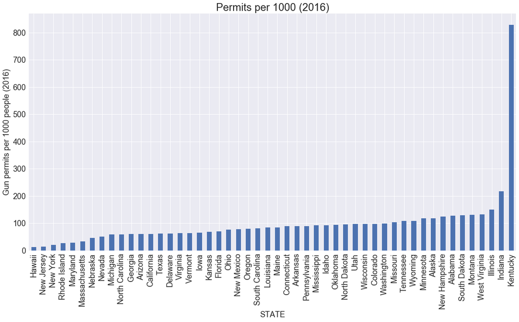

```python
##It is time to plot that column, so that we can compare Permits_per_1000, by state. I also include the sort_index to
## organize in ascending order, so it is easier to visualize.
Final_df.sort_index(by=['Permits_per_1000_2016'], ascending= True).plot(x='state', y='Permits_per_1000_2016', kind = 'bar', figsize=(20,10), legend=False, fontsize=18)
plt.ylabel('Gun permits per 1000 people (2016)', fontsize = 18)
plt.xlabel('STATE', fontsize = 18)
plt.title('Permits per 1000 (2016)', fontsize = 24)
```

Interesting that now California, that was second in total number of firearm checks, now is one of the lower. Kentucky continues to be at the top of the chart. And West Virginia, which in absolute numbers was in the low numbers pack, is now number four like Montana. Texas is now also close to California in terms of firearm checks per 1000 people. It was fourth before.

Here I am now going to do the same excercise for 2010. Then, I will compare gun permits/1000 growth between 2010 and 2016

```python
##First, I extract the gun data for 2010.
gun_data_2010 = gun_data[gun_data['year'] == 2010]
gun_data_2010.head()
```

|  | year | month | state | permit | handgun | long_gun | totals |
| --- | --- | --- | --- | --- | --- | --- | --- |
| 4455 | 2010 | 12 | Alabama | 413.0 | 13978.0 | 24298.0 | 43266 |
| 4456 | 2010 | 12 | Alaska | 0.0 | 2553.0 | 3950.0 | 7036 |
| 4457 | 2010 | 12 | Arizona | 2082.0 | 9943.0 | 9814.0 | 23942 |
| 4458 | 2010 | 12 | Arkansas | 2582.0 | 5816.0 | 12455.0 | 23821 |
| 4459 | 2010 | 12 | California | 24901.0 | 24519.0 | 32100.0 | 81522 |

```python
##Let's group it by state.
guns_by_state_2010 = gun_data_2010.groupby('state')['totals'].sum().reset_index()
```

```python
##Here I rename the column, again, so that I can discriminate between 2010 and 2016.
guns_by_state_2010.rename(columns ={'totals': "Totals 2010"},inplace = True)
```

```python
guns_by_state_2010.head()
```

|  | state | Totals 2010 |
| --- | --- | --- |
| 0 | Alabama | 308607 |
| 1 | Alaska | 65909 |
| 2 | Arizona | 206050 |
| 3 | Arkansas | 191448 |
| 4 | California | 816399 |

```python
## I add the previous coulmn to our dataframe, on state.
Final_df1 = guns_by_state_2010.merge(Final_df, on='state', how='inner')
```

```python
Final_df1.head()
```

|  | state | Totals 2010 | Totals 2016 | Population estimates, July 1, 2016, (V2016) | Population estimates base, April 1, 2010, (V2016) | Population, percent change - April 1, 2010 (estimates base) to July 1, 2016, (V2016) | Population, Census, April 1, 2010 | Persons under 5 years, percent, July 1, 2016, (V2016) | Persons under 5 years, percent, April 1, 2010 | Persons under 18 years, percent, July 1, 2016, (V2016) | ... | Men-owned firms, 2012 | Women-owned firms, 2012 | Minority-owned firms, 2012 | Nonminority-owned firms, 2012 | Veteran-owned firms, 2012 | Nonveteran-owned firms, 2012 | Population per square mile, 2010 | Land area in square miles, 2010 | FIPS Code | Permits_per_1000_2016 |
| --- | --- | --- | --- | --- | --- | --- | --- | --- | --- | --- | --- | --- | --- | --- | --- | --- | --- | --- | --- | --- | --- |
| 0 | Alabama | 308607 | 616947 | 4863300.0 | 4780131.0 | 1.7 | 4779736.0 | 6.0 | 6.4 | 22.600000 | ... | 203604.0 | 137630.0 | 92219.0 | 272651.0 | 41943.0 | 316984.0 | 94.400002 | 50645.328125 | 1.0 | 126.857689 |
| 1 | Alaska | 65909 | 87647 | 741894.0 | 710249.0 | 4.5 | 710231.0 | 7.3 | 7.6 | 25.200001 | ... | 35402.0 | 22141.0 | 13688.0 | 51147.0 | 7953.0 | 56091.0 | 1.200000 | 570640.937500 | 2.0 | 118.139519 |
| 2 | Arizona | 206050 | 416279 | 6931071.0 | 6392301.0 | 8.4 | 6392017.0 | 6.3 | 7.1 | 23.500000 | ... | 245243.0 | 182425.0 | 135313.0 | 344981.0 | 46780.0 | 427582.0 | 56.299999 | 113594.078125 | 4.0 | 60.059838 |
| 3 | Arkansas | 191448 | 266014 | 2988248.0 | 2916025.0 | 2.5 | 2915918.0 | 6.4 | 6.8 | 23.600000 | ... | 123158.0 | 75962.0 | 35982.0 | 189029.0 | 25915.0 | 192988.0 | 56.000000 | 52035.480469 | 5.0 | 89.020055 |
| 4 | California | 816399 | 2377167 | 39250016.0 | 37254520.0 | 5.4 | 37253956.0 | 6.3 | 6.8 | 23.200001 | ... | 1852580.0 | 1320085.0 | 1619857.0 | 1819107.0 | 252377.0 | 3176341.0 | 239.100006 | 155779.218750 | 6.0 | 60.564740 |

5 rows × 69 columns

```python
##Once more, I create another column called "Permits_per_1000_2010" and add it to our dataframe.
Final_df1['Permits_per_1000_2010'] = (Final_df1['Totals 2010']*1000) / Final_df1['Population, Census, April 1, 2010']
```

```python
Final_df1.head()
```

|  | state | Totals 2010 | Totals 2016 | Population estimates, July 1, 2016, (V2016) | Population estimates base, April 1, 2010, (V2016) | Population, percent change - April 1, 2010 (estimates base) to July 1, 2016, (V2016) | Population, Census, April 1, 2010 | Persons under 5 years, percent, July 1, 2016, (V2016) | Persons under 5 years, percent, April 1, 2010 | Persons under 18 years, percent, July 1, 2016, (V2016) | ... | Women-owned firms, 2012 | Minority-owned firms, 2012 | Nonminority-owned firms, 2012 | Veteran-owned firms, 2012 | Nonveteran-owned firms, 2012 | Population per square mile, 2010 | Land area in square miles, 2010 | FIPS Code | Permits_per_1000_2016 | Permits_per_1000_2010 |
| --- | --- | --- | --- | --- | --- | --- | --- | --- | --- | --- | --- | --- | --- | --- | --- | --- | --- | --- | --- | --- | --- |
| 0 | Alabama | 308607 | 616947 | 4863300.0 | 4780131.0 | 1.7 | 4779736.0 | 6.0 | 6.4 | 22.600000 | ... | 137630.0 | 92219.0 | 272651.0 | 41943.0 | 316984.0 | 94.400002 | 50645.328125 | 1.0 | 126.857689 | 64.565700 |
| 1 | Alaska | 65909 | 87647 | 741894.0 | 710249.0 | 4.5 | 710231.0 | 7.3 | 7.6 | 25.200001 | ... | 22141.0 | 13688.0 | 51147.0 | 7953.0 | 56091.0 | 1.200000 | 570640.937500 | 2.0 | 118.139519 | 92.799385 |
| 2 | Arizona | 206050 | 416279 | 6931071.0 | 6392301.0 | 8.4 | 6392017.0 | 6.3 | 7.1 | 23.500000 | ... | 182425.0 | 135313.0 | 344981.0 | 46780.0 | 427582.0 | 56.299999 | 113594.078125 | 4.0 | 60.059838 | 32.235521 |
| 3 | Arkansas | 191448 | 266014 | 2988248.0 | 2916025.0 | 2.5 | 2915918.0 | 6.4 | 6.8 | 23.600000 | ... | 75962.0 | 35982.0 | 189029.0 | 25915.0 | 192988.0 | 56.000000 | 52035.480469 | 5.0 | 89.020055 | 65.656167 |
| 4 | California | 816399 | 2377167 | 39250016.0 | 37254520.0 | 5.4 | 37253956.0 | 6.3 | 6.8 | 23.200001 | ... | 1320085.0 | 1619857.0 | 1819107.0 | 252377.0 | 3176341.0 | 239.100006 | 155779.218750 | 6.0 | 60.564740 | 21.914424 |

5 rows × 70 columns

```
Text(0.5,1,'Permits per 1000 people growth (2010-2016)')
```

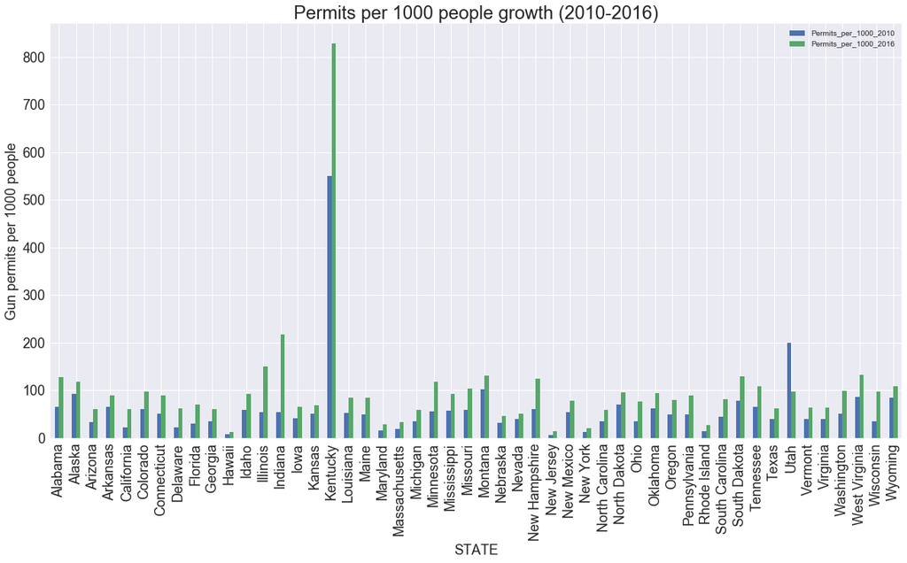

```python
##Time to plot. I've used the side by side histogram, so that I can see increase/decrease for each state.
##It is not easy to see the actual growth, so I will calculate the difference in the next code block.
Final_df1.plot(x="state", y=["Permits_per_1000_2010", "Permits_per_1000_2016"], kind="bar", figsize=(20,10), fontsize=18)
plt.ylabel('Gun permits per 1000 people', fontsize = 18)
plt.xlabel('STATE', fontsize = 18)
plt.title('Permits per 1000 people growth (2010-2016)', fontsize = 24)
```

Interesting enough, when we compare 2010 and 2016, in almost all states we have seen growth in the number of permits/1000 people. In Indiana, it is almost four times higher. Only in Utah, we see a decrease. Utah's firearm laws are some of the more permissive in the United States. In Utah, anyone over the age of 21 can carry a concealed weapon without a permit. This is probably the reason why we don't see an increase in the number of permit requests. It is not because people are not buying guns, but because they do not need a permit. Getting firearms in Utah is easier and easier every year.

In the following blocks we will analyze the difference.

```python
##Here is where I calculate the difference in permits_per_1000 between 2010 and 2016.
Final_df1['Dif 2010-2016'] = Final_df1['Permits_per_1000_2016'] - Final_df1['Permits_per_1000_2010']
```

```python
Final_df1.head()
```

|  | state | Totals 2010 | Totals 2016 | Population estimates, July 1, 2016, (V2016) | Population estimates base, April 1, 2010, (V2016) | Population, percent change - April 1, 2010 (estimates base) to July 1, 2016, (V2016) | Population, Census, April 1, 2010 | Persons under 5 years, percent, July 1, 2016, (V2016) | Persons under 5 years, percent, April 1, 2010 | Persons under 18 years, percent, July 1, 2016, (V2016) | ... | Minority-owned firms, 2012 | Nonminority-owned firms, 2012 | Veteran-owned firms, 2012 | Nonveteran-owned firms, 2012 | Population per square mile, 2010 | Land area in square miles, 2010 | FIPS Code | Permits_per_1000_2016 | Permits_per_1000_2010 | Dif 2010-2016 |
| --- | --- | --- | --- | --- | --- | --- | --- | --- | --- | --- | --- | --- | --- | --- | --- | --- | --- | --- | --- | --- | --- |
| 0 | Alabama | 308607 | 616947 | 4863300.0 | 4780131.0 | 1.7 | 4779736.0 | 6.0 | 6.4 | 22.600000 | ... | 92219.0 | 272651.0 | 41943.0 | 316984.0 | 94.400002 | 50645.328125 | 1.0 | 126.857689 | 64.565700 | 62.291989 |
| 1 | Alaska | 65909 | 87647 | 741894.0 | 710249.0 | 4.5 | 710231.0 | 7.3 | 7.6 | 25.200001 | ... | 13688.0 | 51147.0 | 7953.0 | 56091.0 | 1.200000 | 570640.937500 | 2.0 | 118.139519 | 92.799385 | 25.340134 |
| 2 | Arizona | 206050 | 416279 | 6931071.0 | 6392301.0 | 8.4 | 6392017.0 | 6.3 | 7.1 | 23.500000 | ... | 135313.0 | 344981.0 | 46780.0 | 427582.0 | 56.299999 | 113594.078125 | 4.0 | 60.059838 | 32.235521 | 27.824317 |
| 3 | Arkansas | 191448 | 266014 | 2988248.0 | 2916025.0 | 2.5 | 2915918.0 | 6.4 | 6.8 | 23.600000 | ... | 35982.0 | 189029.0 | 25915.0 | 192988.0 | 56.000000 | 52035.480469 | 5.0 | 89.020055 | 65.656167 | 23.363887 |
| 4 | California | 816399 | 2377167 | 39250016.0 | 37254520.0 | 5.4 | 37253956.0 | 6.3 | 6.8 | 23.200001 | ... | 1619857.0 | 1819107.0 | 252377.0 | 3176341.0 | 239.100006 | 155779.218750 | 6.0 | 60.564740 | 21.914424 | 38.650315 |

5 rows × 71 columns

```
Text(0.5,1,'Permits per 1000 people (difference 2010-2016)')
```

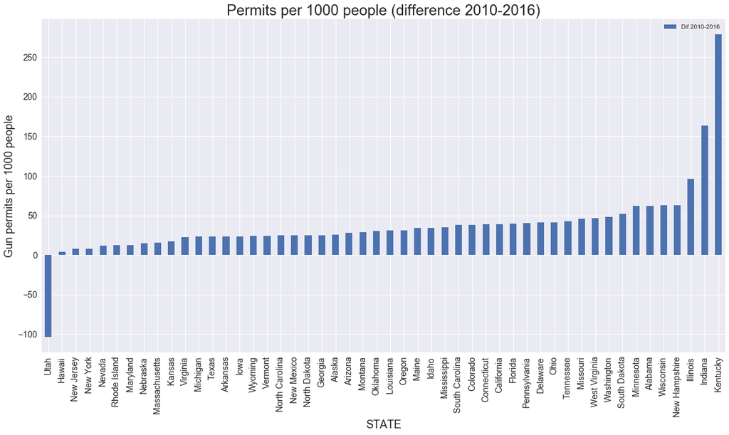

```python
##Time to plot. Now we can see it more clearly and draw conclusions. I also sort them in ascending order.
Final_df1.sort_index(by=['Dif 2010-2016'], ascending= True).plot(x="state", y=["Dif 2010-2016"], kind="bar", figsize=(20,10), fontsize=14)
plt.ylabel('Gun permits per 1000 people', fontsize = 18)
plt.xlabel('STATE', fontsize = 18)
plt.title('Permits per 1000 people (difference 2010-2016)', fontsize = 24)
```

In the above graph we can see that the states with the bigest growth in firearm permits per 1000 are: Kentucky, Indiana, Illinois, followed by New Hampshire, Wisconsin, Alabama and Minnesota. Hawaii is the lowest after Utah, but for very different reasons. Hawaii, with some of the nation’s toughest gun-related laws, keeps a tight rein on gun ownership, registration and use. Hawaii residents cannot purchase a firearm without first getting a permit to acquire the gun. People apply for those permits through the police department, and the department first checks local, state and national databases to see if the applicant has been convicted of a felony or a violent crime, including misdemeanor assaults or domestic violence charges.

In this last section, I will bring in other factors that could posibly influence gun permit checks to answer the FIFTH question.

First, let's take a look at the coulmn headings, to see what data we can use for correlation purposes. Sencond, I will create a table with all correlation numbers. Then, I will use scatter charts to illustrate it.

```python
Final_df1.columns
```

```
Index(['state', 'Totals 2010', 'Totals 2016',
       'Population estimates, July 1, 2016,  (V2016)',
       'Population estimates base, April 1, 2010,  (V2016)',
       'Population, percent change - April 1, 2010 (estimates base) to July 1, 2016,  (V2016)',
       'Population, Census, April 1, 2010',
       'Persons under 5 years, percent, July 1, 2016,  (V2016)',
       'Persons under 5 years, percent, April 1, 2010',
       'Persons under 18 years, percent, July 1, 2016,  (V2016)',
       'Persons under 18 years, percent, April 1, 2010',
       'Persons 65 years and over, percent,  July 1, 2016,  (V2016)',
       'Persons 65 years and over, percent, April 1, 2010',
       'Female persons, percent,  July 1, 2016,  (V2016)',
       'Female persons, percent, April 1, 2010',
       'White alone, percent, July 1, 2016,  (V2016)',
       'Black or African American alone, percent, July 1, 2016,  (V2016)',
       'American Indian and Alaska Native alone, percent, July 1, 2016,  (V2016)',
       'Asian alone, percent, July 1, 2016,  (V2016)',
       'Native Hawaiian and Other Pacific Islander alone, percent, July 1, 2016,  (V2016)',
       'Two or More Races, percent, July 1, 2016,  (V2016)',
       'Hispanic or Latino, percent, July 1, 2016,  (V2016)',
       'White alone, not Hispanic or Latino, percent, July 1, 2016,  (V2016)',
       'Veterans, 2011-2015', 'Foreign born persons, percent, 2011-2015',
       'Housing units,  July 1, 2016,  (V2016)',
       'Housing units, April 1, 2010',
       'Owner-occupied housing unit rate, 2011-2015',
       'Median value of owner-occupied housing units, 2011-2015',
       'Median selected monthly owner costs -with a mortgage, 2011-2015',
       'Median selected monthly owner costs -without a mortgage, 2011-2015',
       'Median gross rent, 2011-2015', 'Building permits, 2016',
       'Households, 2011-2015', 'Persons per household, 2011-2015',
       'Living in same house 1 year ago, percent of persons age 1 year+, 2011-2015',
       'Language other than English spoken at home, percent of persons age 5 years+, 2011-2015',
       'High school graduate or higher, percent of persons age 25 years+, 2011-2015',
       'Bachelor's degree or higher, percent of persons age 25 years+, 2011-2015',
       'With a disability, under age 65 years, percent, 2011-2015',
       'Persons  without health insurance, under age 65 years, percent',
       'In civilian labor force, total, percent of population age 16 years+, 2011-2015',
       'In civilian labor force, female, percent of population age 16 years+, 2011-2015',
       'Total accommodation and food services sales, 2012 ($1,000)',
       'Total health care and social assistance receipts/revenue, 2012 ($1,000)',
       'Total manufacturers shipments, 2012 ($1,000)',
       'Total merchant wholesaler sales, 2012 ($1,000)',
       'Total retail sales, 2012 ($1,000)',
       'Total retail sales per capita, 2012',
       'Mean travel time to work (minutes), workers age 16 years+, 2011-2015',
       'Median household income (in 2015 dollars), 2011-2015',
       'Per capita income in past 12 months (in 2015 dollars), 2011-2015',
       'Persons in poverty, percent', 'Total employer establishments, 2015',
       'Total employment, 2015', 'Total annual payroll, 2015 ($1,000)',
       'Total employment, percent change, 2014-2015',
       'Total nonemployer establishments, 2015', 'All firms, 2012',
       'Men-owned firms, 2012', 'Women-owned firms, 2012',
       'Minority-owned firms, 2012', 'Nonminority-owned firms, 2012',
       'Veteran-owned firms, 2012', 'Nonveteran-owned firms, 2012',
       'Population per square mile, 2010', 'Land area in square miles, 2010',
       'FIPS Code', 'Permits_per_1000_2016', 'Permits_per_1000_2010',
       'Dif 2010-2016'],
      dtype='object')
```

```python
##Here I create a correlation table. I am looking at the Totals 2016 column. Then see the correlation with every row.
Final_df1.corr()
```

|  | Totals 2010 | Totals 2016 | Population estimates, July 1, 2016, (V2016) | Population estimates base, April 1, 2010, (V2016) | Population, percent change - April 1, 2010 (estimates base) to July 1, 2016, (V2016) | Population, Census, April 1, 2010 | Persons under 5 years, percent, July 1, 2016, (V2016) | Persons under 5 years, percent, April 1, 2010 | Persons under 18 years, percent, July 1, 2016, (V2016) | Persons under 18 years, percent, April 1, 2010 | ... | Minority-owned firms, 2012 | Nonminority-owned firms, 2012 | Veteran-owned firms, 2012 | Nonveteran-owned firms, 2012 | Population per square mile, 2010 | Land area in square miles, 2010 | FIPS Code | Permits_per_1000_2016 | Permits_per_1000_2010 | Dif 2010-2016 |
| --- | --- | --- | --- | --- | --- | --- | --- | --- | --- | --- | --- | --- | --- | --- | --- | --- | --- | --- | --- | --- | --- |
| Totals 2010 | 1.000000 | 0.931013 | 0.429226 | 0.428298 | 0.008813 | 0.428299 | 0.110896 | 0.119693 | 0.155202 | 0.166145 | ... | 0.346798 | 0.430587 | 0.428461 | 0.398341 | -0.090279 | 0.051145 | -0.062427 | 0.804849 | 0.775594 | 0.644609 |
| Totals 2016 | 0.931013 | 1.000000 | 0.605044 | 0.607005 | -0.013162 | 0.607001 | 0.022746 | 0.023969 | 0.065580 | 0.090587 | ... | 0.518173 | 0.602010 | 0.593077 | 0.575308 | -0.044947 | 0.052918 | -0.152910 | 0.686741 | 0.570702 | 0.698388 |
| Population estimates, July 1, 2016, (V2016) | 0.429226 | 0.605044 | 1.000000 | 0.999079 | 0.063772 | 0.999078 | -0.000040 | 0.006257 | 0.028916 | 0.091196 | ... | 0.954343 | 0.979373 | 0.985603 | 0.992466 | 0.162460 | 0.138429 | -0.097769 | -0.102701 | -0.162554 | 0.021335 |
| Population estimates base, April 1, 2010, (V2016) | 0.428298 | 0.607005 | 0.999079 | 1.000000 | 0.060007 | 1.000000 | -0.011667 | -0.006688 | 0.018806 | 0.081579 | ... | 0.947094 | 0.983653 | 0.981592 | 0.991785 | 0.172003 | 0.126120 | -0.100028 | -0.100390 | -0.163429 | 0.028237 |
| Population, percent change - April 1, 2010 (estimates base) to July 1, 2016, (V2016) | 0.008813 | -0.013162 | 0.063772 | 0.060007 | 1.000000 | 0.059999 | 0.181682 | 0.234331 | 0.219377 | 0.277980 | ... | 0.061441 | 0.066532 | 0.081335 | 0.063923 | -0.009454 | 0.080753 | -0.218555 | -0.074313 | -0.049702 | -0.095211 |
| Population, Census, April 1, 2010 | 0.428299 | 0.607001 | 0.999078 | 1.000000 | 0.059999 | 1.000000 | -0.011658 | -0.006681 | 0.018814 | 0.081587 | ... | 0.947088 | 0.983651 | 0.981584 | 0.991782 | 0.172001 | 0.126126 | -0.100014 | -0.100388 | -0.163424 | 0.028235 |
| Persons under 5 years, percent, July 1, 2016, (V2016) | 0.110896 | 0.022746 | -0.000040 | -0.011667 | 0.181682 | -0.011658 | 1.000000 | 0.927871 | 0.933638 | 0.825328 | ... | 0.035980 | -0.057876 | -0.024587 | -0.015141 | -0.434285 | 0.476106 | -0.007941 | 0.052451 | 0.207454 | -0.213611 |
| Persons under 5 years, percent, April 1, 2010 | 0.119693 | 0.023969 | 0.006257 | -0.006688 | 0.234331 | -0.006681 | 0.927871 | 1.000000 | 0.980744 | 0.956577 | ... | 0.040068 | -0.056049 | -0.018334 | -0.012596 | -0.420443 | 0.456903 | -0.051078 | 0.037894 | 0.209728 | -0.251828 |
| Persons under 18 years, percent, July 1, 2016, (V2016) | 0.155202 | 0.065580 | 0.028916 | 0.018806 | 0.219377 | 0.018814 | 0.933638 | 0.980744 | 1.000000 | 0.962033 | ... | 0.037759 | -0.024141 | 0.004386 | 0.003216 | -0.395973 | 0.424421 | -0.043495 | 0.063601 | 0.218371 | -0.204962 |
| Persons under 18 years, percent, April 1, 2010 | 0.166145 | 0.090587 | 0.091196 | 0.081579 | 0.277980 | 0.081587 | 0.825328 | 0.956577 | 0.962033 | 1.000000 | ... | 0.091866 | 0.038402 | 0.062687 | 0.063658 | -0.334883 | 0.435184 | -0.116064 | 0.028420 | 0.179814 | -0.225555 |
| Persons 65 years and over, percent, July 1, 2016, (V2016) | -0.176597 | -0.128570 | -0.185680 | -0.180228 | -0.234335 | -0.180248 | -0.728141 | -0.747212 | -0.765433 | -0.769942 | ... | -0.175257 | -0.149121 | -0.155322 | -0.165694 | 0.111397 | -0.548865 | 0.051556 | -0.018056 | -0.134689 | 0.176614 |
| Persons 65 years and over, percent, April 1, 2010 | -0.146452 | -0.098840 | -0.146956 | -0.139493 | -0.215671 | -0.139514 | -0.597412 | -0.698798 | -0.678349 | -0.746000 | ... | -0.154486 | -0.097081 | -0.118563 | -0.127016 | 0.170992 | -0.611786 | 0.078665 | -0.016905 | -0.127400 | 0.167469 |
| Female persons, percent, July 1, 2016, (V2016) | 0.108044 | 0.144967 | 0.224346 | 0.235018 | 0.044383 | 0.235009 | -0.554453 | -0.452287 | -0.406481 | -0.318506 | ... | 0.145981 | 0.270324 | 0.268182 | 0.213386 | 0.506151 | -0.655337 | -0.057011 | -0.068164 | -0.166150 | 0.109073 |
| Female persons, percent, April 1, 2010 | 0.096419 | 0.132788 | 0.203904 | 0.216910 | 0.014566 | 0.216902 | -0.569318 | -0.512856 | -0.452785 | -0.389511 | ... | 0.114560 | 0.263714 | 0.244871 | 0.195487 | 0.550951 | -0.687350 | -0.014255 | -0.061001 | -0.164324 | 0.123078 |
| White alone, percent, July 1, 2016, (V2016) | 0.068217 | 0.030178 | -0.171441 | -0.173354 | -0.241401 | -0.173350 | -0.107755 | -0.063170 | -0.027480 | -0.030002 | ... | -0.217125 | -0.128945 | -0.190796 | -0.172422 | -0.209203 | -0.024998 | 0.292186 | 0.223479 | 0.239902 | 0.138998 |
| Black or African American alone, percent, July 1, 2016, (V2016) | -0.052082 | -0.050653 | 0.002963 | 0.003389 | 0.190638 | 0.003381 | 0.035045 | 0.129021 | 0.137160 | 0.159709 | ... | 0.021701 | 0.000211 | 0.036492 | 0.007207 | 0.026456 | -0.059140 | -0.203355 | -0.042078 | -0.055319 | -0.009638 |
| American Indian and Alaska Native alone, percent, July 1, 2016, (V2016) | -0.028559 | 0.006995 | -0.071450 | -0.063487 | 0.117007 | -0.063507 | -0.328954 | -0.327196 | -0.278141 | -0.241611 | ... | -0.044149 | -0.060585 | -0.038055 | -0.055757 | 0.284171 | -0.290109 | -0.365311 | 0.012425 | -0.063486 | 0.132882 |
| Asian alone, percent, July 1, 2016, (V2016) | -0.106330 | -0.105211 | -0.064382 | -0.064434 | -0.560977 | -0.064427 | -0.116750 | -0.173692 | -0.199817 | -0.258415 | ... | -0.010393 | -0.093834 | -0.088318 | -0.053237 | -0.041280 | 0.032346 | 0.101046 | -0.014061 | 0.014753 | -0.057369 |
| Native Hawaiian and Other Pacific Islander alone, percent, July 1, 2016, (V2016) | 0.035377 | 0.111927 | 0.180347 | 0.174065 | 0.065550 | 0.174071 | -0.011341 | 0.059185 | 0.002845 | 0.073614 | ... | 0.196323 | 0.128068 | 0.128934 | 0.167340 | -0.124472 | 0.051899 | -0.134872 | -0.040973 | -0.068680 | 0.014749 |
| Two or More Races, percent, July 1, 2016, (V2016) | -0.136742 | -0.138087 | -0.092148 | -0.095096 | 0.023952 | -0.095091 | 0.146913 | 0.056942 | -0.011466 | -0.041865 | ... | -0.024072 | -0.136146 | -0.111548 | -0.083528 | -0.022477 | 0.114884 | -0.158209 | -0.135104 | -0.105825 | -0.147903 |
| Hispanic or Latino, percent, July 1, 2016, (V2016) | 0.119630 | 0.204916 | 0.533321 | 0.520492 | 0.074974 | 0.520492 | 0.131939 | 0.252300 | 0.191972 | 0.297498 | ... | 0.596196 | 0.458308 | 0.502307 | 0.538277 | 0.125398 | 0.261148 | -0.141925 | -0.211870 | -0.189488 | -0.193605 |
| White alone, not Hispanic or Latino, percent, July 1, 2016, (V2016) | -0.034951 | -0.117245 | -0.462279 | -0.455394 | -0.232200 | -0.455390 | -0.171247 | -0.213858 | -0.153302 | -0.219735 | ... | -0.533409 | -0.382133 | -0.460368 | -0.463622 | -0.212490 | -0.185436 | 0.308418 | 0.288711 | 0.289801 | 0.212358 |
| Veterans, 2011-2015 | 0.447818 | 0.615875 | 0.964008 | 0.959414 | 0.075717 | 0.959403 | -0.032935 | -0.026973 | -0.004741 | 0.052957 | ... | 0.896873 | 0.951574 | 0.984562 | 0.945456 | 0.117336 | 0.116092 | -0.074973 | -0.090916 | -0.163618 | 0.051006 |
| Foreign born persons, percent, 2011-2015 | 0.064847 | 0.184739 | 0.631668 | 0.628954 | 0.075938 | 0.628954 | -0.082371 | -0.044979 | -0.099466 | -0.002241 | ... | 0.680774 | 0.606564 | 0.602673 | 0.663230 | 0.520741 | 0.050349 | -0.194534 | -0.311184 | -0.309720 | -0.233188 |
| Housing units, July 1, 2016, (V2016) | 0.434742 | 0.608313 | 0.993921 | 0.993583 | 0.067686 | 0.993578 | -0.032358 | -0.029613 | -0.003099 | 0.057273 | ... | 0.934609 | 0.987837 | 0.991887 | 0.986680 | 0.169135 | 0.112593 | -0.090105 | -0.099464 | -0.167327 | 0.036785 |
| Housing units, April 1, 2010 | 0.432725 | 0.608964 | 0.992830 | 0.993617 | 0.065268 | 0.993612 | -0.042763 | -0.040478 | -0.013109 | 0.047986 | ... | 0.930731 | 0.990322 | 0.989318 | 0.986500 | 0.176185 | 0.103838 | -0.094920 | -0.098376 | -0.168218 | 0.040815 |
| Owner-occupied housing unit rate, 2011-2015 | -0.055127 | -0.125348 | -0.464911 | -0.462899 | -0.138237 | -0.462910 | -0.113155 | -0.070814 | 0.003934 | -0.021491 | ... | -0.512943 | -0.433406 | -0.428984 | -0.487948 | -0.227758 | -0.209846 | 0.125394 | 0.200884 | 0.188487 | 0.169191 |
| Median value of owner-occupied housing units, 2011-2015 | -0.165491 | -0.110192 | 0.181585 | 0.184186 | 0.035896 | 0.184203 | -0.163890 | -0.173731 | -0.254555 | -0.194650 | ... | 0.249595 | 0.161171 | 0.129749 | 0.216418 | 0.460058 | -0.008987 | -0.135753 | -0.270584 | -0.233634 | -0.260883 |
| Median selected monthly owner costs -with a mortgage, 2011-2015 | -0.138470 | -0.066193 | 0.282559 | 0.287915 | 0.060433 | 0.287929 | -0.256614 | -0.253971 | -0.297979 | -0.208759 | ... | 0.323365 | 0.284126 | 0.240823 | 0.318369 | 0.652118 | 0.017078 | -0.114089 | -0.300724 | -0.288902 | -0.242304 |
| Median selected monthly owner costs -without a mortgage, 2011-2015 | -0.193487 | -0.140668 | 0.123078 | 0.133460 | 0.024899 | 0.133468 | -0.436049 | -0.442015 | -0.419733 | -0.337832 | ... | 0.121274 | 0.171410 | 0.096183 | 0.159078 | 0.748141 | -0.121387 | 0.012909 | -0.250903 | -0.275693 | -0.145707 |
| ... | ... | ... | ... | ... | ... | ... | ... | ... | ... | ... | ... | ... | ... | ... | ... | ... | ... | ... | ... | ... | ... |
| In civilian labor force, total, percent of population age 16 years+, 2011-2015 | -0.244469 | -0.233447 | -0.129965 | -0.130106 | 0.171572 | -0.130092 | 0.178580 | 0.109647 | 0.128688 | 0.104414 | ... | -0.126520 | -0.099444 | -0.150881 | -0.110877 | 0.144104 | 0.135497 | 0.126165 | -0.185202 | -0.142197 | -0.207422 |
| In civilian labor force, female, percent of population age 16 years+, 2011-2015 | -0.300232 | -0.280375 | -0.207878 | -0.206070 | 0.174483 | -0.206058 | 0.058223 | -0.034343 | -0.022600 | -0.051753 | ... | -0.198077 | -0.171733 | -0.219023 | -0.185085 | 0.156658 | 0.124348 | 0.098378 | -0.179122 | -0.170784 | -0.146437 |
| Total accommodation and food services sales, 2012 ($1,000) | 0.368977 | 0.551547 | 0.970800 | 0.969884 | 0.062014 | 0.969882 | -0.021501 | -0.015384 | -0.016577 | 0.050645 | ... | 0.956444 | 0.946633 | 0.950951 | 0.977483 | 0.175409 | 0.136371 | -0.129092 | -0.136851 | -0.191159 | -0.013028 |
| Total health care and social assistance receipts/revenue, 2012 ($1,000) | 0.395210 | 0.576308 | 0.983826 | 0.988668 | 0.046449 | 0.988669 | -0.060822 | -0.069446 | -0.042857 | 0.016865 | ... | 0.924216 | 0.987466 | 0.960212 | 0.984713 | 0.228194 | 0.094153 | -0.094807 | -0.112825 | -0.178392 | 0.023133 |
| Total manufacturers shipments, 2012 ($1,000) | 0.475874 | 0.615899 | 0.815229 | 0.813157 | 0.071033 | 0.813167 | 0.179034 | 0.152015 | 0.221464 | 0.260224 | ... | 0.709677 | 0.781028 | 0.799383 | 0.760999 | 0.004880 | 0.484669 | -0.032927 | 0.009580 | -0.073423 | 0.142251 |
| Total merchant wholesaler sales, 2012 ($1,000) | 0.415278 | 0.566527 | 0.940590 | 0.937626 | 0.036940 | 0.937632 | 0.040208 | 0.037965 | 0.080228 | 0.132555 | ... | 0.907055 | 0.907496 | 0.916479 | 0.930900 | 0.243521 | 0.175478 | -0.062958 | -0.095239 | -0.148292 | 0.015790 |
| Total retail sales, 2012 ($1,000) | 0.425513 | 0.602288 | 0.996996 | 0.996181 | 0.061626 | 0.996180 | -0.012414 | -0.013301 | 0.012370 | 0.071351 | ... | 0.944719 | 0.981606 | 0.984328 | 0.988947 | 0.182061 | 0.128556 | -0.076124 | -0.107368 | -0.170526 | 0.023257 |
| Total retail sales per capita, 2012 | -0.250144 | -0.254278 | -0.254001 | -0.260328 | 0.063958 | -0.260323 | 0.025894 | -0.148286 | -0.137934 | -0.244185 | ... | -0.195809 | -0.258778 | -0.259851 | -0.232958 | -0.122067 | -0.008278 | 0.208107 | -0.050115 | -0.044955 | -0.045577 |
| Mean travel time to work (minutes), workers age 16 years+, 2011-2015 | 0.140676 | 0.224793 | 0.495131 | 0.504535 | -0.083272 | 0.504536 | -0.447631 | -0.381754 | -0.382857 | -0.266537 | ... | 0.445048 | 0.525827 | 0.503296 | 0.501587 | 0.596175 | -0.320563 | -0.104568 | -0.164423 | -0.234091 | -0.008456 |
| Median household income (in 2015 dollars), 2011-2015 | -0.210629 | -0.180135 | 0.061277 | 0.063779 | 0.041482 | 0.063795 | -0.045973 | -0.086310 | -0.107108 | -0.066037 | ... | 0.089123 | 0.066350 | 0.028132 | 0.085229 | 0.500967 | 0.129426 | -0.072768 | -0.264063 | -0.223475 | -0.261974 |
| Per capita income in past 12 months (in 2015 dollars), 2011-2015 | -0.214868 | -0.159145 | 0.084369 | 0.090733 | 0.000510 | 0.090747 | -0.294441 | -0.366284 | -0.363813 | -0.336712 | ... | 0.082937 | 0.124954 | 0.069652 | 0.113635 | 0.601579 | -0.011334 | -0.029184 | -0.247494 | -0.271221 | -0.144910 |
| Persons in poverty, percent | 0.317190 | 0.296955 | 0.153962 | 0.154227 | -0.012927 | 0.154217 | 0.069159 | 0.130447 | 0.146732 | 0.144679 | ... | 0.145218 | 0.123010 | 0.169143 | 0.132500 | -0.268606 | -0.026274 | -0.060844 | 0.260177 | 0.217463 | 0.262556 |
| Total employer establishments, 2015 | 0.400579 | 0.581394 | 0.992033 | 0.993046 | 0.057798 | 0.993044 | -0.029421 | -0.028166 | -0.011136 | 0.048710 | ... | 0.950791 | 0.987031 | 0.977271 | 0.996336 | 0.188385 | 0.116097 | -0.106585 | -0.117567 | -0.176400 | 0.008646 |
| Total employment, 2015 | 0.423267 | 0.602338 | 0.996481 | 0.997424 | 0.056565 | 0.997423 | -0.016391 | -0.016377 | 0.010591 | 0.071241 | ... | 0.939074 | 0.988990 | 0.982583 | 0.990760 | 0.188398 | 0.121522 | -0.088910 | -0.108306 | -0.172481 | 0.024217 |
| Total annual payroll, 2015 ($1,000) | 0.381763 | 0.560165 | 0.982880 | 0.986250 | 0.043376 | 0.986256 | -0.024259 | -0.026611 | -0.005178 | 0.056620 | ... | 0.936833 | 0.974983 | 0.951299 | 0.984538 | 0.221727 | 0.123447 | -0.092756 | -0.126646 | -0.183592 | -0.001162 |
| Total employment, percent change, 2014-2015 | -0.051685 | -0.045889 | 0.034255 | 0.034667 | 0.643640 | 0.034668 | 0.167650 | 0.161218 | 0.131358 | 0.171051 | ... | 0.051079 | 0.033511 | 0.030526 | 0.044076 | 0.241354 | 0.119063 | -0.271882 | -0.118124 | -0.103862 | -0.111093 |
| Total nonemployer establishments, 2015 | 0.403217 | 0.578422 | 0.991291 | 0.988214 | 0.069635 | 0.988208 | -0.007655 | -0.002407 | 0.010866 | 0.070865 | ... | 0.976960 | 0.968556 | 0.985459 | 0.997703 | 0.168550 | 0.142474 | -0.131080 | -0.117594 | -0.169067 | -0.003364 |
| All firms, 2012 | 0.402368 | 0.578637 | 0.993865 | 0.992858 | 0.065681 | 0.992854 | -0.015042 | -0.011944 | 0.004473 | 0.064899 | ... | 0.969147 | 0.978079 | 0.982512 | 0.999816 | 0.177226 | 0.133118 | -0.122717 | -0.117391 | -0.171316 | 0.000780 |
| Men-owned firms, 2012 | 0.401807 | 0.573995 | 0.992564 | 0.992857 | 0.062033 | 0.992855 | -0.027980 | -0.028052 | -0.008331 | 0.051131 | ... | 0.960089 | 0.983320 | 0.980985 | 0.998510 | 0.199661 | 0.121403 | -0.110488 | -0.118196 | -0.172266 | 0.000418 |
| Women-owned firms, 2012 | 0.394416 | 0.572664 | 0.989937 | 0.987899 | 0.068124 | 0.987893 | -0.010978 | -0.006027 | 0.006670 | 0.067467 | ... | 0.976863 | 0.968860 | 0.981545 | 0.998283 | 0.163683 | 0.138893 | -0.138537 | -0.122122 | -0.175480 | -0.003651 |
| Minority-owned firms, 2012 | 0.346798 | 0.518173 | 0.954343 | 0.947094 | 0.061441 | 0.947088 | 0.035980 | 0.040068 | 0.037759 | 0.091866 | ... | 1.000000 | 0.896618 | 0.941242 | 0.970346 | 0.141527 | 0.190558 | -0.156739 | -0.140664 | -0.176174 | -0.046480 |
| Nonminority-owned firms, 2012 | 0.430587 | 0.602010 | 0.979373 | 0.983653 | 0.066532 | 0.983651 | -0.057876 | -0.056049 | -0.024141 | 0.038402 | ... | 0.896618 | 1.000000 | 0.970953 | 0.976694 | 0.199733 | 0.077379 | -0.087560 | -0.091809 | -0.158753 | 0.040964 |
| Veteran-owned firms, 2012 | 0.428461 | 0.593077 | 0.985603 | 0.981592 | 0.081335 | 0.981584 | -0.024587 | -0.018334 | 0.004386 | 0.062687 | ... | 0.941242 | 0.970953 | 1.000000 | 0.978878 | 0.160562 | 0.123188 | -0.094424 | -0.112511 | -0.173497 | 0.015903 |
| Nonveteran-owned firms, 2012 | 0.398341 | 0.575308 | 0.992466 | 0.991785 | 0.063923 | 0.991782 | -0.015141 | -0.012596 | 0.003216 | 0.063658 | ... | 0.970346 | 0.976694 | 0.978878 | 1.000000 | 0.180175 | 0.133214 | -0.125790 | -0.118006 | -0.171032 | -0.001140 |
| Population per square mile, 2010 | -0.090279 | -0.044947 | 0.162460 | 0.172003 | -0.009454 | 0.172001 | -0.434285 | -0.420443 | -0.395973 | -0.334883 | ... | 0.141527 | 0.199733 | 0.160562 | 0.180175 | 1.000000 | -0.346546 | -0.048328 | -0.202479 | -0.237845 | -0.092564 |
| Land area in square miles, 2010 | 0.051145 | 0.052918 | 0.138429 | 0.126120 | 0.080753 | 0.126126 | 0.476106 | 0.456903 | 0.424421 | 0.435184 | ... | 0.190558 | 0.077379 | 0.123188 | 0.133214 | -0.346546 | 1.000000 | -0.187749 | 0.007806 | 0.066799 | -0.090316 |
| FIPS Code | -0.062427 | -0.152910 | -0.097769 | -0.100028 | -0.218555 | -0.100014 | -0.007941 | -0.051078 | -0.043495 | -0.116064 | ... | -0.156739 | -0.087560 | -0.094424 | -0.125790 | -0.048328 | -0.187749 | 1.000000 | -0.072295 | 0.001989 | -0.174638 |
| Permits_per_1000_2016 | 0.804849 | 0.686741 | -0.102701 | -0.100390 | -0.074313 | -0.100388 | 0.052451 | 0.037894 | 0.063601 | 0.028420 | ... | -0.140664 | -0.091809 | -0.112511 | -0.118006 | -0.202479 | 0.007806 | -0.072295 | 1.000000 | 0.941757 | 0.836574 |
| Permits_per_1000_2010 | 0.775594 | 0.570702 | -0.162554 | -0.163429 | -0.049702 | -0.163424 | 0.207454 | 0.209728 | 0.218371 | 0.179814 | ... | -0.176174 | -0.158753 | -0.173497 | -0.171032 | -0.237845 | 0.066799 | 0.001989 | 0.941757 | 1.000000 | 0.603609 |
| Dif 2010-2016 | 0.644609 | 0.698388 | 0.021335 | 0.028237 | -0.095211 | 0.028235 | -0.213611 | -0.251828 | -0.204962 | -0.225555 | ... | -0.046480 | 0.040964 | 0.015903 | -0.001140 | -0.092564 | -0.090316 | -0.174638 | 0.836574 | 0.603609 | 1.000000 |

70 rows × 70 columns

```
Text(0.5,1,'Correlation between Gun Permit Requests and Population')
```

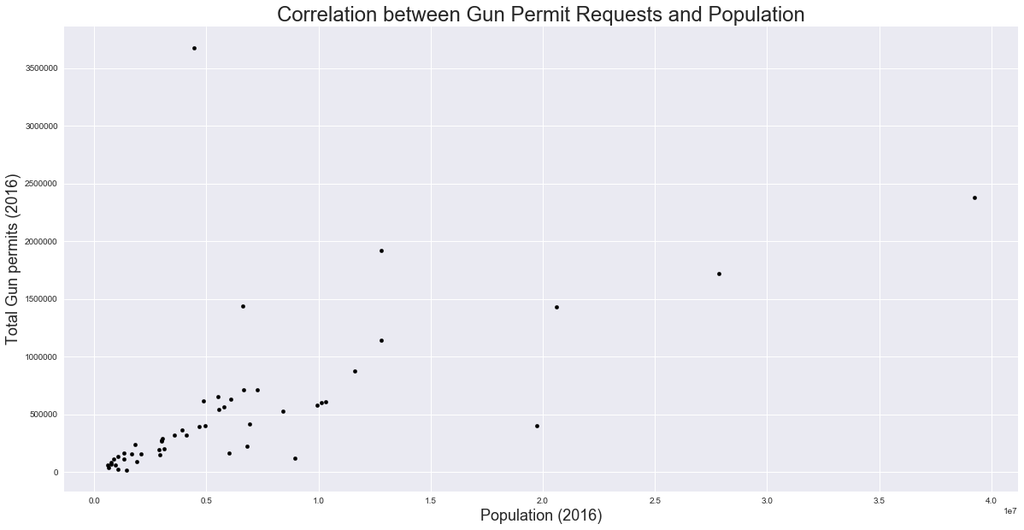

```python
##I will be using the scatter function in the following blocks.
Final_df1.plot.scatter(x='Population estimates, July 1, 2016,  (V2016)', y='Totals 2016', figsize=(20,10), c='black' );
plt.ylabel('Total Gun permits (2016)', fontsize = 18)
plt.xlabel('Population (2016)', fontsize = 18)
plt.title('Correlation between Gun Permit Requests and Population', fontsize = 24)
```

Logicaly, there is some positive correlation (0.605044) between the Population in 2016 and the total number of gun permit requests during that year.

```
Text(0.5,1,'Correlation between Gun Permit Requests and % of American Indian and Alaska Native')
```

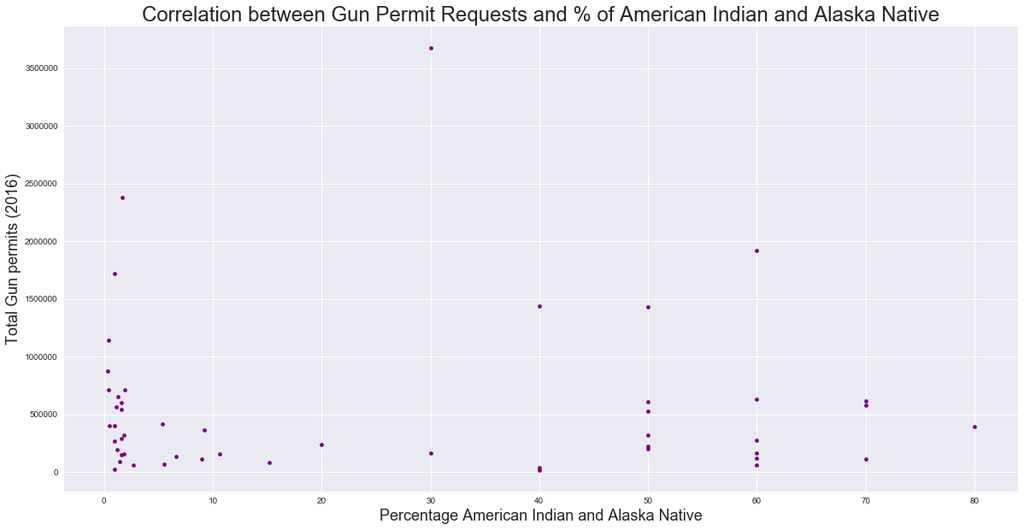

```python
Final_df1.plot.scatter(x='American Indian and Alaska Native alone, percent, July 1, 2016,  (V2016)', y='Totals 2016',figsize=(20,10),c='purple' );
plt.ylabel('Total Gun permits (2016)', fontsize = 18)
plt.xlabel('Percentage American Indian and Alaska Native', fontsize = 18)
plt.title('Correlation between Gun Permit Requests and % of American Indian and Alaska Native', fontsize = 24)
```

```
Text(0.5,1,'Correlation between Gun Permit Requests and % White alone, not Hispanic or Latino ')
```

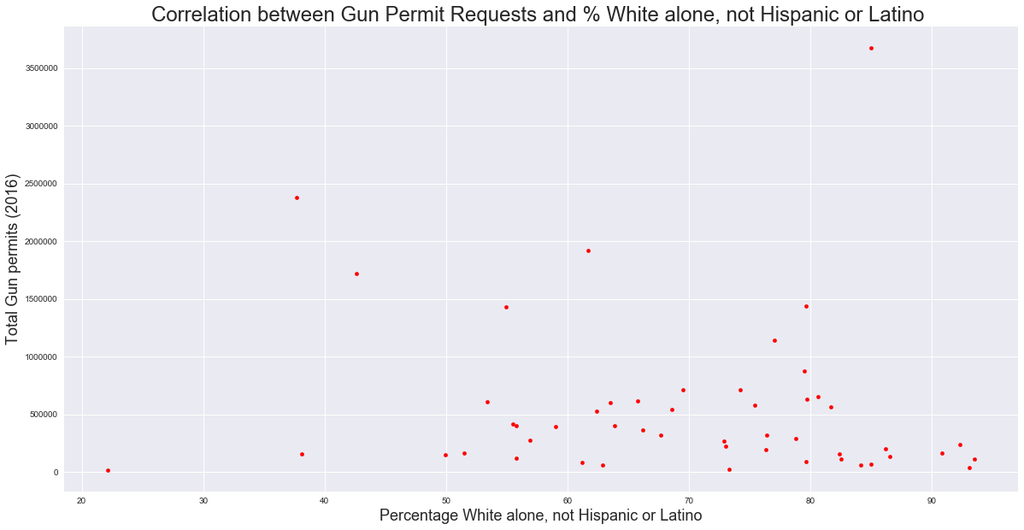

```python
Final_df1.plot.scatter(x='White alone, not Hispanic or Latino, percent, July 1, 2016,  (V2016)', y='Totals 2016',figsize=(20,10), c='red' );
plt.ylabel('Total Gun permits (2016)', fontsize = 18)
plt.xlabel('Percentage White alone, not Hispanic or Latino', fontsize = 18)
plt.title('Correlation between Gun Permit Requests and % White alone, not Hispanic or Latino ', fontsize = 24)
```

```
Text(0.5,1,'Correlation between Gun Permit Requests and Percentage of Black or African American')
```

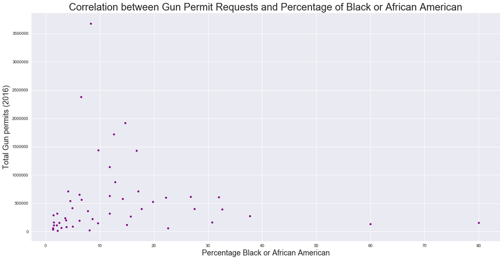

```python
Final_df1.plot.scatter(x='Black or African American alone, percent, July 1, 2016,  (V2016)', y='Totals 2016',figsize=(20,10),c='purple' );
plt.ylabel('Total Gun permits (2016)', fontsize = 18)
plt.xlabel('Percentage Black or African American', fontsize = 18)
plt.title('Correlation between Gun Permit Requests and Percentage of Black or African American', fontsize = 24)
```

```
Text(0.5,1,'Correlation between Gun Permit Requests and Age')
```

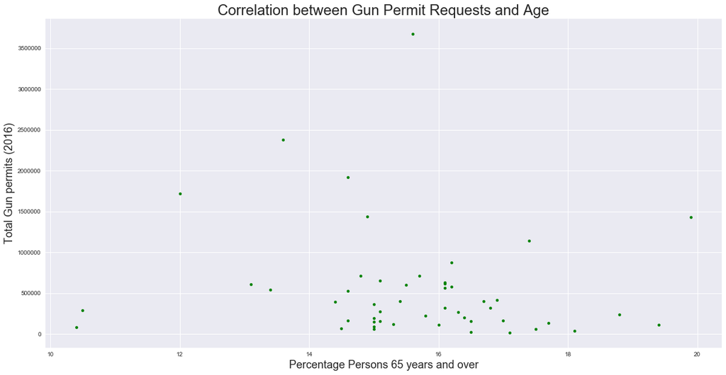

```python
Final_df1.plot.scatter(x='Persons 65 years and over, percent,  July 1, 2016,  (V2016)', y='Totals 2016', figsize=(20,10), c='green' );
plt.ylabel('Total Gun permits (2016)', fontsize = 18)
plt.xlabel('Percentage Persons 65 years and over', fontsize = 18)
plt.title('Correlation between Gun Permit Requests and Age', fontsize = 24)
```

```
Text(0.5,1,'Correlation between Gun Permit Requests and Gender')
```

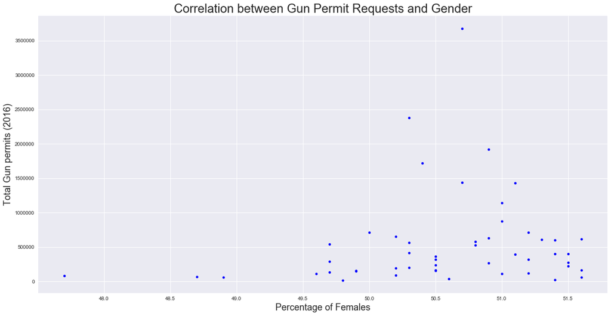

```python
Final_df1.plot.scatter(x='Female persons, percent,  July 1, 2016,  (V2016)', y='Totals 2016', figsize=(20,10), c='blue' );
plt.ylabel('Total Gun permits (2016)', fontsize = 18)
plt.xlabel('Percentage of Females', fontsize = 18)
plt.title('Correlation between Gun Permit Requests and Gender', fontsize = 24)
```

```
Text(0.5,1,'Correlation between Gun Permit Requests and Income Level')
```

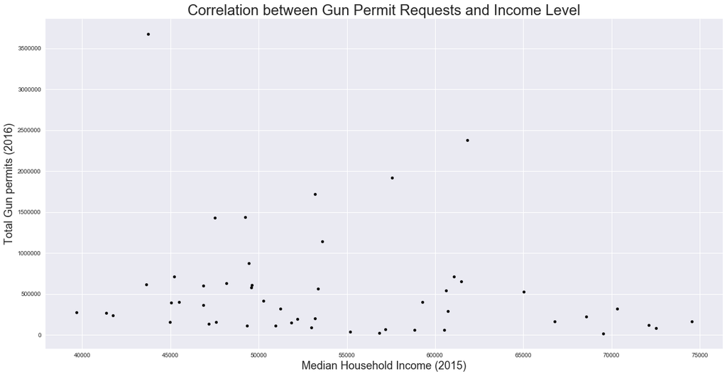

```python
Final_df1.plot.scatter(x='Median household income (in 2015 dollars), 2011-2015', y='Totals 2016', figsize=(20,10), c='black' );
plt.ylabel('Total Gun permits (2016)', fontsize = 18)
plt.xlabel('Median Household Income (2015)', fontsize = 18)
plt.title('Correlation between Gun Permit Requests and Income Level', fontsize = 24)
```

In the chart above, we observe low negative correlation (-0.180135) between income level and permit checks.

```
Text(0.5,1,'Correlation between Gun Permit Requests and Education')
```

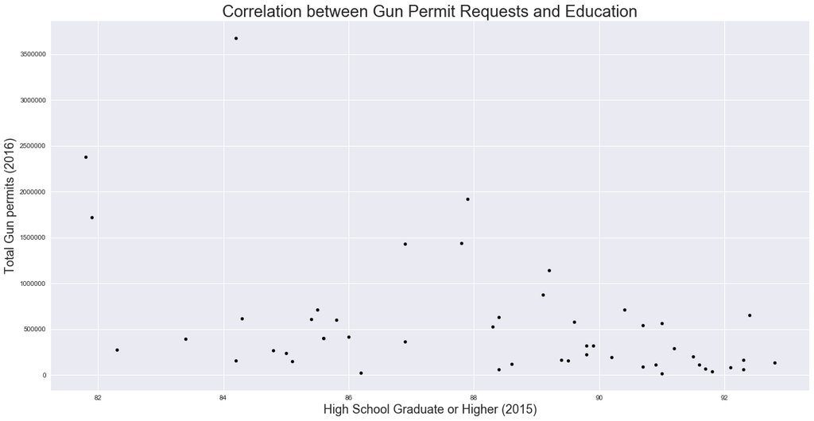

```python
Final_df1.plot.scatter(x='High school graduate or higher, percent of persons age 25 years+, 2011-2015', y='Totals 2016', figsize=(20,10), c='black' );
plt.ylabel('Total Gun permits (2016)', fontsize = 18)
plt.xlabel('High School Graduate or Higher (2015)', fontsize = 18)
plt.title('Correlation between Gun Permit Requests and Education', fontsize = 24)
```

```python
##The correlation number of the above scatter chart does not appear in the table. I will calculate it using .corr
Final_df1['Totals 2016'].corr(Final_df1['High school graduate or higher, percent of persons age 25 years+, 2011-2015'])
```

```
-0.43105287362285705
```

## Conclusions

> When doing this analysis, I encountered a couple of limitations in our datafiles. First, firearm checks does not equate to firearm sales. Second, low numbers on firearm permit checks does not allways means less guns. In some cases it means the state has more relaxed gun laws. This is the case for Utah.

> I observed steady annual increases in firearm permit checks. This is specially true in 2016.

> I detected an increase in the number of firearm checks during December. This is traditionaly the biggest month in terms of retail sales. It obviously applies to firearms. It must be apopular gift.

> Kentucky stood up in every analysis. In absolute, in relative to population and in 10 year growth numbers.